# Predicting Attacks on Civilians in the Eastern Democratic Republic of Congo: Feature Engineering

#### Variable: **Minimum distance to the border with contiguous countries**

```r
# For every fishnet grid cell in the 3 Eastern DRC provinces under consideration, I will personally calculate the distances to the entire DRC country borders with neighboring countries, and find the minimum distance among these for each grid cell.

# Read the DRC map and transform to WGS 84 (lat/lon)
drc_map <- st_read('COD_adm/COD_adm0.shp') %>%
  st_transform(crs = 4326)

# Create the DRC boundary. drc_map is a single polygon for the country
drc_boundary <- st_boundary(drc_map) %>%
  st_cast("MULTILINESTRING")

# Convert the boundary to MULTIPOLYGON.
drc_border <- drc_boundary %>%
  st_combine() %>%
  st_cast("MULTIPOLYGON")


# Calculate distances
# Transform to a projected CRS that's suitable for distance measurement in the DRC region
proj_crs <- st_crs(projected_crs) # Using the same projected CRS suitable for Eastern DRC as before

drc_border_proj <- st_transform(drc_border, crs = proj_crs)

# Calculate the distances in meters
distances_to_border <- st_distance(fishnet, drc_border_proj)

# Use apply() to calculate the minimum value across rows of the distances matrix
min_distances <- apply(distances_to_border, 1, min)

# Add the minimum distances to the fishnet data
distances_to_border_sf <- fishnet

distances_to_border_sf$min_distance_to_border <- min_distances

# Step 5: Merge with vars_in_net
distances_to_border_sf_subset <- distances_to_border_sf[, c("uniqueID", "min_distance_to_border")]

vars_in_net <- merge(vars_in_net, as(distances_to_border_sf_subset, "Spatial"), by = "uniqueID", all.x = TRUE)


# saveRDS(vars_in_net, file = "vars_in_net-after_distance_to_border_added.rds", compress = TRUE)
# vars_in_net <- readRDS(file = "vars_in_net-after_distance_to_border_added.rds")
```

#### Variable: **Total mines controlled by armed groups**

```r
library(tidyr)

# Variable: Armed Mines
# This variable comes from the IPIS dataset "Artisanal Mining Sites in Eastern DRC" (https://ipisresearch.be/project/mapping-artisanal-small-scale-mining-in-eastern-drc/). The dataset's variables - "armed_group1", "armed_group2", and "armed_group3" - provide the names of armed groups that maintained a presence, if any, at any given mine. I will filter out the categories of "None", NA, and government forces such as the "FARDC", which is the Armed Forces of the Democratic Republic of the Congo, "Police des Mines (PMH)", and "Police Nationale Congolaise (sauf PMH)", leaving us with mines occupied by NSAGs.

e_drc_mines <- read.csv("eastern_drc_mines-ipis.csv")
e_drc_mines <- e_drc_mines %>%
  dplyr::select(vid, # unique ID for each mine
         longitude,
         latitude,
         is_3t_mine,
         is_gold_mine,
         presence, # Whether or not there are any armed groups at a given mine
         armed_group1, # The dataset lists up to 3 armed groups stationed at each mine
         armed_group2,
         armed_group3,
         )

e_drc_mines <- e_drc_mines %>%
  st_as_sf(coords = c("longitude", "latitude"), crs = 4326) %>%
  st_transform(crs = projected_crs)

e_drc_mines.expanded <- tidyr::gather(data = e_drc_mines, key = "armed_group_number", value = "armed_group", armed_group1, armed_group2, armed_group3)

# I will remove the following values from the armed_group column. The first 3 are government organizations.
values_to_remove <- c('FARDC', 'Police Nationale Congolaise (sauf PMH)', 'Police des Mines (PMH)', 'None')

e_drc_mines.expanded <- e_drc_mines.expanded %>%
  filter(presence == 1,
         !is.na(armed_group),
         nzchar(armed_group),
         !(armed_group %in% values_to_remove)) %>%
  distinct(vid, .keep_all = TRUE)

# Having removed all government organizations, 'None' values, potential NA values, and blank cells, the only armed groups left are non-state armed groups (NSAGs).

e_drc_mines.expanded_sf <- e_drc_mines.expanded %>%
  st_as_sf(coords = c("longitude", "latitude"), crs = 4326) %>%
  st_transform(crs = crs(fishnet))


# Perform the spatial intersection
intersection <- st_intersection(fishnet, e_drc_mines.expanded_sf)

# Remove empty geometries resulting from the intersection
intersection <- intersection[!st_is_empty(intersection), ]

print(sum(is.na(intersection$altitude))) # Shows there are no NA values


# saveRDS(intersection, file = "e_drc_mines.expanded_sf-before_sum.rds", compress = TRUE)

# intersection <- readRDS(file = "e_drc_mines.expanded_sf-before_sum.rds")

# Use unique identifier for each geometry in the intersection result to find the total mines with NSAGs present per grid cell
total_armed_e_drc_mines <- intersection %>%
  group_by(uniqueID) %>%
  summarise(total_armed_mines = sum(presence, na.rm = TRUE)) %>%
  ungroup()


# Drop geometry from intersection before the join
total_armed_e_drc_mines_no_geom <- as.data.frame(total_armed_e_drc_mines) %>%
  dplyr::select(-c(geometry))


print(dim(total_armed_e_drc_mines_no_geom)) # Output shows 388 grid cells/rows with armed mine.

# Join the counts back with the original fishnet geometry
total_armed_mines_sf <- left_join(fishnet, total_armed_e_drc_mines_no_geom, by = "uniqueID")

# See if any NA values exist after using left_join
print(sum(is.na(total_armed_mines_sf$total_armed_mines))) # Shows there are 8021 NA values.
print(dim(fishnet)) # shows 8409 grid cells


# Recall before the left join, we saw there were 388 grid cells/rows with armed mines. Since 388 armed mines + 8021 NA values = 8409, we know the only NA values that exist are from grid cells that did not have any mines occupied by NSAGs. We can therefore replace these NA values with 0.

total_armed_mines_sf$total_armed_mines[is.na(total_armed_mines_sf$total_armed_mines)] <- 0


# saveRDS(total_armed_mines_sf, file = "total_armed_mines_sf-finished.rds", compress = TRUE)

# total_armed_mines_sf <- readRDS(file = "total_armed_mines_sf-finished.rds")

total_armed_mines_sf_subset <- total_armed_mines_sf[, c("uniqueID", "total_armed_mines")]


# Perform the join using base R's merge function
vars_in_net <- merge(vars_in_net, as(total_armed_mines_sf_subset, "Spatial"), by = "uniqueID", all.x = TRUE)
```

#### Variable: **Weighted harmonic mean Inverse-Distance Weighted (IDW) distance to mines armed by NSAGs**

```r
# The following code calculates the weighted harmonic mean of mines armed by NSAGs - using the inverse of the distances to the nearest neighboring grid cells and number of armed mines per grid cell, and sets k=3

weighted_harmonic_avg_dists <- function(sf_data, column, sf_data_centroids, neighbors_weights, k_value) {

  weighted_harmonic_avg_distances <- vector("numeric", nrow(sf_data))

  for (i in 1:nrow(sf_data)) {
    # Retrieve neighbor indices, excluding the ego grid cell itself
    current_neighbors <- neighbors_weights$neighbours[[i]]
    current_neighbors <- current_neighbors[current_neighbors != i]

    # Keep/consider only neighbors with at least one NSAG
    neighbors_with_quantity <- current_neighbors[sf_data[[column]][current_neighbors] > 0]

    # Calculate distances to from cell i (the ego cell) to these neighbors
    if (length(neighbors_with_quantity) > 0) {
      distances <- st_distance(sf_data_centroids[i, , drop = FALSE],
                               sf_data_centroids[neighbors_with_quantity, , drop = FALSE])

      # Convert distance to numeric and sort distances in order to ensure we're using the closest k neighbors
      distances <- as.numeric(distances)
      sorted_indices <- order(distances)
      distances <- distances[sorted_indices]
      neighbors_with_quantity <- neighbors_with_quantity[sorted_indices]

      # Automatically adjust k based on the number of available neighbors with NSAGs, starting with 3 neighbors and decreasing to 2 or 1 if needed
      k_adj <- min(k_value, length(neighbors_with_quantity))

      # Calculate the weighted harmonic mean
      if (sum(sf_data[[column]][neighbors_with_quantity][1:k_adj]) > 0 && sum(1/distances[1:k_adj]) > 0) {
        weighted_harmonic_avg_distances[i] <- sum(sf_data[[column]][neighbors_with_quantity][1:k_adj]) /
                                              sum((sf_data[[column]][neighbors_with_quantity][1:k_adj]) / distances[1:k_adj])
      } else {
        weighted_harmonic_avg_distances[i] <- NA  # Safety check: If no neighbors with NSAGs or distances are zero, assign NA
      }
    } else {
      weighted_harmonic_avg_distances[i] <- NA  # Safety check: If no neighbors or all neighbors have zero NSAGs, assign NA
    }
  }
  return(weighted_harmonic_avg_distances)
}

# Convert the sf object to centroids
total_armed_mines_sf_centroids <- st_centroid(total_armed_mines_sf)

# Ensure the centroids are in a projected CRS appropriate for distance calculations
total_armed_mines_sf_centroids <- st_transform(total_armed_mines_sf_centroids, crs = st_crs(fishnet))

# Convert the sf centroids object to sp class for using with spdep functions
total_armed_mines_sp_centroids <- as(total_armed_mines_sf_centroids, "Spatial")

# Create a neighbors list
nearest_neighbors_list <- dnearneigh(coordinates(total_armed_mines_sp_centroids), 0, Inf, longlat = FALSE)

# Create spatial weights using IDW. This weights matrix can be reused for other spatial objects with centroids regardless of differences in values, because the weights matrix depends on the locations of the centroids - not their values. This will save time.
neighbors_weights <- nb2listwdist(nearest_neighbors_list, x = total_armed_mines_sp_centroids, type = "idw", style = "raw", zero.policy = TRUE)

# saveRDS(neighbors_weights, "neighbors_weights.rds", compress = TRUE)
# neighbors_weights <- readRDS("neighbors_weights.rds")

# Use the weighted_harmonic_avg_dists function to calculate weighted harmonic average distances
weighted_harmonic_avg_distances <- weighted_harmonic_avg_dists(
  sf_data = total_armed_mines_sf,         # Spatial data object
  column = "total_armed_mines",           # Column with the number of armed mines
  sf_data_centroids = total_armed_mines_sf_centroids,  # Centroids of the grid cells
  neighbors_weights = neighbors_weights,  # Spatial weights created using IDW
  k_value = 3                             # Starting with 3 neighbors, will adjust if fewer exist
)

# Assign the weighted harmonic average distances to the sf object
total_armed_mines_sf$weighted_harmonic_avg_distance_to_armed_mines <- weighted_harmonic_avg_distances

# Subset relevant columns
total_armed_mines_sf_subset <- total_armed_mines_sf[, c("uniqueID", "total_armed_mines", "weighted_harmonic_avg_distance_to_armed_mines")]

# Merge variables to vars_in_net
vars_in_net <- merge(vars_in_net, as(total_armed_mines_sf_subset, "Spatial"), by = "uniqueID", all.x = TRUE)

# Save object
# saveRDS(vars_in_net, file = "vars_in_net-after_armed_mines_added.rds", compress = TRUE)
```

#### Variable: **Total number of mines**

```r
# Use st_within to find mines within polygons
mines_in_fishnet <- st_within(e_drc_mines, fishnet, sparse = FALSE)

# Convert the logical matrix to a numeric matrix
mines_in_fishnet_numeric <- matrix(as.numeric(mines_in_fishnet), nrow = nrow(mines_in_fishnet))

# Count the number of mines in each polygon
total_mines_per_cell <- colSums(mines_in_fishnet_numeric)

# Create a data frame (optional)
total_mines_per_cell <- data.frame(uniqueID = fishnet$uniqueID, total_mines = total_mines_per_cell)

total_mines_per_cell_sf <- left_join(fishnet, total_mines_per_cell, by = "uniqueID")

saveRDS(total_mines_per_cell_sf, file = "total_mines_per_cell_sf.rds", compress = TRUE)

# total_mines_per_cell_sf <- readRDS(file = "total_mines_per_cell_sf.rds")

total_mines_per_cell_sf_subset <- total_mines_per_cell_sf[, c("uniqueID", "total_mines")]

# vars_in_net <- merge(vars_in_net, as(total_mines_per_cell_sf_subset, "Spatial"), by = "uniqueID", all.x = TRUE)
```

#### Variable: **Weighted harmonic mean IDW distance to the nearest mines, regardless of type**

```r
# Convert the sf object to centroids
total_mines_per_cell_sf_centroids <- st_centroid(total_mines_per_cell_sf_subset)

# Ensure the centroids are in a projected CRS appropriate for distance calculations
total_mines_per_cell_sf_centroids <- st_transform(total_mines_per_cell_sf_centroids, crs = st_crs(fishnet))

# There is no need to create a new neighbors_weights matrix object. The previous neighbors_weights can simply be reused in the weighted_harmonic_avg_dists() function below for the reasons previously explained.

weighted_harmonic_avg_distance_to_mines <- weighted_harmonic_avg_dists(
  sf_data = total_mines_per_cell_sf_subset,
  column = "total_mines",
  sf_data_centroids = total_mines_per_cell_sf_centroids,
  neighbors_weights = neighbors_weights,
  k_value = 3
)

# Assign the weighted harmonic average distances to the sf object
total_mines_per_cell_sf_subset$weighted_harmonic_avg_distance_to_mines <- weighted_harmonic_avg_distances

total_mines_per_cell_sf_subset <- total_mines_per_cell_sf_subset[, c("uniqueID", "total_mines", "weighted_harmonic_avg_distance_to_mines")]

# Merge variables to vars_in_net
vars_in_net <- merge(vars_in_net, as(total_mines_per_cell_sf_subset, "Spatial"), by = "uniqueID", all.x = TRUE)

# Save object
# saveRDS(vars_in_net, file = "vars_in_net-after_mines_added.rds", compress = TRUE)
# vars_in_net <- readRDS(file = "vars_in_net-after_mines_added.rds")
```

#### Variable: **Total number of 3T (tin, tantalum, tungsten) mines**

```r
e_drc_mines_intersection <- st_intersection(fishnet[,"uniqueID", "geometry"], e_drc_mines)

e_drc_mines.3t <- e_drc_mines_intersection %>%
  dplyr::filter(is_3t_mine == 1)

# Use st_within to find mines within polygons
mines_3t_in_fishnet <- st_within(e_drc_mines.3t, fishnet, sparse = FALSE)

# Convert the logical matrix to a numeric matrix
mines_3t_in_fishnet_numeric <- matrix(as.numeric(mines_3t_in_fishnet), nrow = nrow(mines_3t_in_fishnet))

# Count the number of mines in each polygon
total_3t_mines_per_cell <- colSums(mines_3t_in_fishnet_numeric)

# Create a data frame (optional)
total_3t_mines_per_cell <- data.frame(uniqueID = fishnet$uniqueID, total_3t_mines = total_3t_mines_per_cell)


total_3t_mines_per_cell_sf <- left_join(fishnet, total_3t_mines_per_cell, by = "uniqueID")

# saveRDS(total_3t_mines_per_cell_sf, file = "total_3t_mines_per_cell_sf.rds", compress = TRUE)

# total_3t_mines_per_cell_sf <- readRDS(file = "total_3t_mines_per_cell_sf.rds")

total_3t_mines_per_cell_sf_subset <- total_3t_mines_per_cell_sf[, c("uniqueID", "total_3t_mines")]

# vars_in_net <- merge(vars_in_net, as(total_3t_mines_per_cell_sf_subset, "Spatial"), by = "uniqueID", all.x = TRUE)
```

#### Variable: **Weighted harmonic mean IDW distance to the nearest 3T mines**

```r
# Convert the sf object to centroids
total_3t_mines_per_cell_sf_centroids <- st_centroid(total_3t_mines_per_cell_sf_subset)

# Ensure the centroids are in a projected CRS appropriate for distance calculations
total_3t_mines_per_cell_sf_centroids <- st_transform(total_3t_mines_per_cell_sf_centroids, crs = st_crs(fishnet))

# The previous neighbors_weights can simply be reused in the weighted_harmonic_avg_dists() function below for the reasons previously mentioned.

weighted_harmonic_avg_distance_to_3t_mines <- weighted_harmonic_avg_dists(
  sf_data = total_3t_mines_per_cell_sf_subset,
  column = "total_3t_mines",
  sf_data_centroids = total_3t_mines_per_cell_sf_centroids,
  neighbors_weights = neighbors_weights,
  k_value = 3
)

# Assign the weighted harmonic average distances to the sf object
total_3t_mines_per_cell_sf_subset$weighted_harmonic_avg_distance_to_3t_mines <- weighted_harmonic_avg_distances

total_3t_mines_per_cell_sf_subset <- total_3t_mines_per_cell_sf_subset[, c("uniqueID", "total_3t_mines", "weighted_harmonic_avg_distance_to_3t_mines")]

# Merge variables to vars_in_net
vars_in_net <- merge(vars_in_net, as(total_3t_mines_per_cell_sf_subset, "Spatial"), by = "uniqueID", all.x = TRUE)

# Save object
# saveRDS(vars_in_net, file = "vars_in_net-after_3t_mines_added.rds", compress = TRUE)
# vars_in_net <- readRDS(file = "vars_in_net-after_3t_mines_added.rds")
```

#### Variable: **Total number of gold mines**

```r
e_drc_mines.gold <- e_drc_mines_intersection %>%
  dplyr::filter(is_gold_mine == 1)

# Use st_within to find mines within polygons
gold_mines_in_fishnet <- st_within(e_drc_mines.gold, fishnet, sparse = FALSE)

# Convert the logical matrix to a numeric matrix
gold_mines_in_fishnet_numeric <- matrix(as.numeric(gold_mines_in_fishnet), nrow = nrow(gold_mines_in_fishnet))

# Count the number of mines in each polygon
total_gold_mines_per_cell <- colSums(gold_mines_in_fishnet_numeric)

# Create a data frame (optional)
total_gold_mines_per_cell <- data.frame(uniqueID = fishnet$uniqueID, total_gold_mines = total_gold_mines_per_cell)

total_gold_mines_per_cell_sf <- left_join(fishnet, total_gold_mines_per_cell, by = "uniqueID")

# saveRDS(total_gold_mines_per_cell_sf, file = "total_gold_mines_per_cell_sf.rds", compress = TRUE)

# total_gold_mines_per_cell_sf <- readRDS(file = "total_gold_mines_per_cell_sf.rds")

total_gold_mines_per_cell_sf_subset <- total_gold_mines_per_cell_sf[, c("uniqueID", "total_gold_mines")]

# vars_in_net <- merge(vars_in_net, as(total_gold_mines_per_cell_sf_subset, "Spatial"), by = "uniqueID", all.x = TRUE)
```

#### Variable: **Weighted harmonic mean IDW distance to the nearest gold mines**

```r
# Convert the sf object to centroids
total_gold_mines_per_cell_sf_centroids <- st_centroid(total_gold_mines_per_cell_sf_subset)

# Ensure the centroids are in a projected CRS appropriate for distance calculations
total_gold_mines_per_cell_sf_centroids <- st_transform(total_gold_mines_per_cell_sf_centroids, crs = st_crs(fishnet))

weighted_harmonic_avg_distance_to_gold_mines <- weighted_harmonic_avg_dists(
  sf_data = total_3t_mines_per_cell_sf_subset,
  column = "total_3t_mines",
  sf_data_centroids = total_3t_mines_per_cell_sf_centroids,
  neighbors_weights = neighbors_weights,
  k_value = 3
)

# Assign the weighted harmonic average distances to the sf object
total_gold_mines_per_cell_sf_subset$weighted_harmonic_avg_distance_to_gold_mines <- weighted_harmonic_avg_distances

total_gold_mines_per_cell_sf_subset <- total_gold_mines_per_cell_sf_subset[, c("uniqueID", "total_gold_mines", "weighted_harmonic_avg_distance_to_gold_mines")]

# Merge variables to vars_in_net
vars_in_net <- merge(vars_in_net, as(total_gold_mines_per_cell_sf_subset, "Spatial"), by = "uniqueID", all.x = TRUE)

# Save object
# saveRDS(vars_in_net, file = "vars_in_net-after_gold_mines_added.rds", compress = TRUE)
# vars_in_net <- readRDS(file = "vars_in_net-after_3t_mines_added.rds")
```

#### Variable: **Total number of active non-state armed groups (NSAGs) per grid cell**

```r
# Number of active non-state armed groups per grid cell
# The categories for inter1 and inter2 variables are found in the "ACLED Codebook" (Jan. 2021, pg. 3)

acled <- readRDS("acled.rds")

acled$inter1 <- factor(acled$inter1,
                         levels = c(1, 2, 3, 4, 5, 6, 7, 8),
                         labels = c("State Forces", "Rebel Groups", "Political Militias", "Identity Militias", "Rioters", "Protesters", "Civilians", "External/Other Forces"))

acled$inter2 <- factor(acled$inter2,
                         levels = c(1, 2, 3, 4, 5, 6, 7, 8),
                         labels = c("State Forces", "Rebel Groups", "Political Militias", "Identity Militias", "Rioters", "Protesters", "Civilians", "External/Other Forces"))

violent_events = subset(acled, event_type %in% c('Battles', 'Explosions/Remote violence', 'Violence against civilians'))


# Ensure that both inter1 and inter2 have the same attributes
violent_events$inter1 <- factor(violent_events$inter1, levels = levels(acled$inter1))
violent_events$inter2 <- factor(violent_events$inter2, levels = levels(acled$inter2))


desired_values = c("Rebel Groups", "Political Militias", "Identity Militias")

# Convert violent_events to expanded format via gather()
violent_events.expanded <- tidyr::gather(data = violent_events, key = "interaction_number", value = "nsag", inter1, inter2)

# By specifying the columns in the line above (inter1 and inter2), I ensure that gather() only combines inter1 and inter2 into a single column ("nsag") rather than attempting to combine other columns, with interaction_number indicating whether the original data came from inter1 or inter2.


# Filter violent_events_expanded for only NSAGs as actors
violent_events.expanded <- violent_events.expanded %>%
  filter(nsag %in% desired_values)


# Next, I must combine actor1, assoc_actor_1, actor2, and assoc_actor_2 columns as the names of specific armed groups are listed in these.

violent_events.expanded.nsags <- tidyr::gather(data = violent_events, key = "actor", value = "nsag_name", actor1, assoc_actor_1, actor2, assoc_actor_2)


# In the commented out code below, I wrote the dataframe to a CSV file to manually check which nsag_name values should be removed (those that are not NSAGs). I also manually removed them via Excel.
# write.csv(violent_events.expanded.nsags, file = "violent_events_expanded_nsags.csv", row.names = FALSE)


# In the commented out code below, I imported the reviewed and filtered version of violent_events.expanded.nsags:

violent_events.expanded.nsags.reviewed <- read.csv("violent_events_expanded_nsags-reviewed.csv", stringsAsFactors = FALSE)

violent_events.expanded.nsags.reviewed$event_date <- as.Date(violent_events.expanded.nsags.reviewed$event_date, format = "%m/%d/%Y")


# I will summarize  the process I followed when reviewing the non-state armed groups (NSAGs) in the csv file:

# The ACLED categories that I combined into the "nsag_name" column consist of columns "actor1", "assoc_actor_1", "actor2", and "assoc_actor_2". Each of these columns can contain the names of armed groups, but also many other types of names of categories of actors, including government actors (e.g., military, police) and a large variety of civilian and ordinary organization actors (e.g., health workers).

# Because there were many, I carefully reviewed, research, and manually identify which organizations were names of armed groups in the DRC, and which organizations were not. Only those names that were found to be non-state armed groups (NSAGs) were kept. NSAGs with the word "unidentified" in them were not kept - since it would be impossible to know if such a group represented a unique armed group or if it would be double counted when I later count the number of unique NSAGs in any given fishnet grid cell. There were also many NA values in the "nsag_name" column which I had to delete. Many of these NA values represent unidentified armed groups engaged in violent acts.

# Thus, my count of the number of distinct armed groups active in each fishnet grid cell represent only those in which the names were recorded by ACLED. As such, there are likely many more unidentified armed groups that could have been distinct armed groups in any given grid cell had their names been known. Naturally, armed groups involved in violence may have incentives to keep their identity unknown. As a result, my count of distinct NSAGs in each grid cell will likely not be fully accurate. Nonetheless, what is most important is to see whether the counts of distinct identified armed groups known for sure to have been engaged in political violence carry enough signal rather than noise that they can be used in my ML model as a fairly accurate predictor of future trends of violence against civilians in a given grid cell location.


# Set it as an sf object with the correct geographic CRS
violent_events.expanded.nsags.reviewed <- st_as_sf(
  violent_events.expanded.nsags.reviewed,
  coords = c("longitude", "latitude"),
  crs = 4326 # WGS 84 coordinate reference system
)

# Now transform to the projected CRS of fishnet
violent_events.expanded.nsags.reviewed <- st_transform(
  violent_events.expanded.nsags.reviewed,
  st_crs(fishnet)
)

violent_events.expanded.nsags.reviewed_train <- filter(violent_events.expanded.nsags.reviewed, event_date < as.Date("2023-07-01"))
violent_events.expanded.nsags.reviewed_test <- dplyr::filter(violent_events.expanded.nsags.reviewed, event_date >= as.Date("2023-07-01"))

# Perform the spatial intersection
intersection_train.nsags <- st_intersection(fishnet, violent_events.expanded.nsags.reviewed_train)
intersection_test.nsags <- st_intersection(fishnet, violent_events.expanded.nsags.reviewed_test)

print(sum(is.na(intersection_train.nsags$nsag_name))) # Shows there are no NAs
print(sum(is.na(intersection_test.nsags$nsag_name))) # Shows there are no NAs

# Generate a unique identifier for each geometry in the intersection result
unique_nsags_intersection_train <- intersection_train.nsags %>%
  group_by(uniqueID) %>%
  summarise(unique_nsags = n_distinct(nsag_name, na.rm = TRUE)) %>%
  ungroup()

unique_nsags_intersection_test <- intersection_test.nsags %>%
  group_by(uniqueID) %>%
  summarise(unique_nsags = n_distinct(nsag_name, na.rm = TRUE)) %>%
  ungroup()

# Drop geometry from intersection before the join
unique_nsags_intersection_no_geom_train <- as.data.frame(unique_nsags_intersection_train)
unique_nsags_intersection_no_geom_train <- unique_nsags_intersection_no_geom_train %>% dplyr::select(-c(geometry))

unique_nsags_intersection_no_geom_test <- as.data.frame(unique_nsags_intersection_test)
unique_nsags_intersection_no_geom_test <- unique_nsags_intersection_no_geom_test %>% dplyr::select(-c(geometry))

# Join the counts back with the original fishnet geometry
# Now you can use left_join because intersection_no_geom is a regular data frame
nsags_count_sf_train <- left_join(fishnet, unique_nsags_intersection_no_geom_train, by = "uniqueID")
nsags_count_sf_test <- left_join(fishnet, unique_nsags_intersection_no_geom_test, by = "uniqueID")

# Replace NA values with 0 in the unique_nsags column
nsags_count_sf_train$unique_nsags <- replace_na(nsags_count_sf_train$unique_nsags, 0)
nsags_count_sf_test$unique_nsags <- replace_na(nsags_count_sf_test$unique_nsags, 0)
```

#### Variable: **Weighted harmonic mean IDW distance to each grid cell’s k = 3 nearest neighbors who have at least 1 active NSAG present, weighted by the total number of NSAGs present**

```r
# Why do I include the requirement that neighboring grid cells have at least 1 NSAG? The weighted average is meant to represent an actual measured value (in this case, distance weighted by NSAG counts). If the weights are all zero because there are no NSAGs in the neighboring cells, this essentially means there is no data to calculate a meaningful average distance for that particular cell, hence NA (not available) is more appropriate to signify the absence of data. Since When you calculate a weighted average, the formula involves summing up the product of each value and its corresponding weight and then dividing this sum by the total sum of weights, if all weights are zero, the sum of weights is zero, leading to a situation where you divide by zero, which is mathematically undefined and would typically result in an infinite (Inf) value.

# If we simply substituted 0 instead of Inf, this would incorrectly imply the average distance is zero, which has a different meaning (suggesting that the NSAGs are exactly at the location of the cell in question, which would not be the case here).

# Convert the sf object to centroids
nsags_count_sf_centroids_train <- st_centroid(nsags_count_sf_train)
nsags_count_sf_centroids_test <- st_centroid(nsags_count_sf_test)

# Ensure the centroids are in a projected CRS appropriate for distance calculations
nsags_count_sf_centroids_train <- st_transform(nsags_count_sf_centroids_train, crs = st_crs(fishnet))
nsags_count_sf_centroids_test <- st_transform(nsags_count_sf_centroids_test, crs = st_crs(fishnet))

# In theory, we could also use just nsags_count_sf_centroids_train to place in both train and test set versions of the weighted_harmonic_avg_dists() function below since nsags_count_sf_centroids_train and nsags_count_sf_centroids_test share exactly the same spatial coordinates. However, for clarity, I use nsags_count_sf_centroids_train in the training set version of the weighted_harmonic_avg_dists() function and nsags_count_sf_centroids_test in the test set version of weighted_harmonic_avg_dists().


weighted_harmonic_avg_distances_train.nsags <- weighted_harmonic_avg_dists(
  sf_data = nsags_count_sf_train,
  column = "unique_nsags",
  sf_data_centroids = nsags_count_sf_centroids_train,
  neighbors_weights = neighbors_weights,
  k_value = 3
)

weighted_harmonic_avg_distances_test.nsags <- weighted_harmonic_avg_dists(
  sf_data = nsags_count_sf_test,
  column = "unique_nsags",
  sf_data_centroids = nsags_count_sf_centroids_test,
  neighbors_weights = neighbors_weights,
  k_value = 3
)

# Train
# Assign the weighted harmonic average distances to the sf object
nsags_count_sf_train$weighted_harmonic_avg_distance_to_NSAGs <- weighted_harmonic_avg_distances_train.nsags

nsags_count_sf_subset_train <- nsags_count_sf_train[, c("uniqueID", "unique_nsags", "weighted_harmonic_avg_distance_to_NSAGs")]

# Merge variables to vars_in_net
vars_in_net_train <- merge(vars_in_net, as(nsags_count_sf_subset_train, "Spatial"), by = "uniqueID", all.x = TRUE)

# Test
# Assign the weighted harmonic average distances to the sf object
nsags_count_sf_test$weighted_harmonic_avg_distance_to_NSAGs <- weighted_harmonic_avg_distances_test.nsags

nsags_count_sf_subset_test <- nsags_count_sf_test[, c("uniqueID", "unique_nsags", "weighted_harmonic_avg_distance_to_NSAGs")]


# Merge variables to vars_in_net
vars_in_net_test <- merge(vars_in_net, as(nsags_count_sf_subset_test, "Spatial"), by = "uniqueID", all.x = TRUE)

# saveRDS(vars_in_net_train, file = "vars_in_net_train-after_nsags_added.rds", compress = TRUE)
# saveRDS(vars_in_net_test, file = "vars_in_net_test-after_nsags_added.rds", compress = TRUE)

# vars_in_net_train <- readRDS(file = "vars_in_net_train-after_nsags_added.rds")
# vars_in_net_test <- readRDS(file = "vars_in_net_test-after_nsags_added.rds")
```

#### Variable: **Total number of territorial seizures**

```r
# Variable - Seizure of territory either by NSAGs or by government forces.

# I will count the number of forceful territorial seizures (by either the government or NSAGs) in each fishnet grid cell. As before, I will also calculate the weighted harmonic mean distance from each grid cell to the 3 nearest neighboring cells in which at least 1 territorial seizure occurred.

territory_taken_train = subset(acled, sub_event_type %in% c('Non-state actor overtakes territory', 'Government regains territory')) %>%
  filter(event_date < as.Date("2023-07-01")) %>%
  dplyr::select(longitude, latitude, sub_event_type) %>%
  mutate(countLandSeizures = 1) %>%
  mutate(territory_taker = sub_event_type)


territory_taken_test = subset(acled, sub_event_type %in% c('Non-state actor overtakes territory', 'Government regains territory')) %>%
  filter(event_date >= as.Date("2023-07-01")) %>%
  dplyr::select(longitude, latitude, sub_event_type) %>%
  mutate(countLandSeizures = 1) %>%
  mutate(territory_taker = sub_event_type)


# Set it as an sf object with the correct geographic CRS
territory_taken_train <- st_as_sf(
  territory_taken_train,
  coords = c("longitude", "latitude"),
  crs = 4326 # WGS 84 coordinate reference system
)


territory_taken_test <- st_as_sf(
  territory_taken_test,
  coords = c("longitude", "latitude"),
  crs = 4326 # WGS 84 coordinate reference system
)


# Now transform to the projected CRS of fishnet
territory_taken_train <- st_transform(
  territory_taken_train,
  st_crs(fishnet)
)


territory_taken_test <- st_transform(
  territory_taken_test,
  st_crs(fishnet)
)


# Perform the spatial intersection
intersection_train.territory <- st_intersection(fishnet, territory_taken_train)
intersection_test.territory <- st_intersection(fishnet, territory_taken_test)


sum(is.na(intersection_train.territory$countLandSeizures)) # Shows there are no NAs
sum(is.na(intersection_test.territory$countLandSeizures)) # Shows there are no NAs


# Calculate the sum total of land seizures which occurred in each grid cell
total_land_seizures_intersection_train <- intersection_train.territory %>%
  group_by(uniqueID) %>%
  summarise(total_land_seizures = sum(countLandSeizures, na.rm = TRUE)) %>%
  ungroup()

sum(total_land_seizures_intersection_train$total_land_seizures) # There were 679 total land seizures


total_land_seizures_intersection_test <- intersection_test.territory %>%
  group_by(uniqueID) %>%
  summarise(total_land_seizures = sum(countLandSeizures, na.rm = TRUE)) %>%
  ungroup()

sum(total_land_seizures_intersection_test$total_land_seizures) # There were 34 total land seizures


# Drop geometry from intersection before the join
total_land_seizures_intersection_no_geom_train <- as.data.frame(total_land_seizures_intersection_train) %>%
  dplyr::select(-c(geometry)) # Delete geometry in order to perform the left join below


total_land_seizures_intersection_no_geom_test <- as.data.frame(total_land_seizures_intersection_test) %>%
  dplyr::select(-c(geometry))


# Join the counts back with the original fishnet geometry
land_seizure_count_sf_train <- left_join(fishnet, total_land_seizures_intersection_no_geom_train, by = "uniqueID")
land_seizure_count_sf_test <- left_join(fishnet, total_land_seizures_intersection_no_geom_test, by = "uniqueID")


# Print the number sum total to verify whether the land seizure count is the same or whether any excess NAs were introduced
sum(land_seizure_count_sf_train$total_land_seizures, na.rm = TRUE) # No new NAs introduced by the left join
sum(land_seizure_count_sf_test$total_land_seizures, na.rm = TRUE) # No new NAs introduced by the left join


# Replace NA values with 0 in the unique_nsags column. 0 is the value these NAs had before the left join
land_seizure_count_sf_train$total_land_seizures <- replace_na(land_seizure_count_sf_train$total_land_seizures, 0)
land_seizure_count_sf_test$total_land_seizures <- replace_na(land_seizure_count_sf_test$total_land_seizures, 0)


# Ensure the result is an sf object with geometry
land_seizure_count_sf_train <- st_sf(land_seizure_count_sf_train, geometry = st_geometry(fishnet), crs = st_crs(fishnet))
land_seizure_count_sf_test <- st_sf(land_seizure_count_sf_test, geometry = st_geometry(fishnet), crs = st_crs(fishnet))
```

#### Variable: **Weighted harmonic mean IDW distance to the nearest territorial seizures**

```r
# Convert the sf object to centroids
land_seizure_count_sf_centroids_train <- st_centroid(land_seizure_count_sf_train)
land_seizure_count_sf_centroids_test <- st_centroid(land_seizure_count_sf_test)

# Ensure the centroids are in a projected CRS appropriate for distance calculations
land_seizure_count_sf_centroids_train <- st_transform(land_seizure_count_sf_centroids_train, crs = st_crs(fishnet))
land_seizure_count_sf_centroids_test <- st_transform(land_seizure_count_sf_centroids_test, crs = st_crs(fishnet))


weighted_harmonic_avg_distances_train.land <- weighted_harmonic_avg_dists(
  sf_data = land_seizure_count_sf_train,
  column = "total_land_seizures",
  sf_data_centroids = land_seizure_count_sf_centroids_train,
  neighbors_weights = neighbors_weights,
  k_value = 3
)

weighted_harmonic_avg_distances_test.land <- weighted_harmonic_avg_dists(
  sf_data = land_seizure_count_sf_test,
  column = "total_land_seizures",
  sf_data_centroids = land_seizure_count_sf_centroids_test,
  neighbors_weights = neighbors_weights,
  k_value = 3
)


# Assign the weighted harmonic average distances to the sf object
land_seizure_count_sf_train$weighted_harmonic_avg_distance_to_land_seizures <- weighted_harmonic_avg_distances_train.land
land_seizure_count_sf_test$weighted_harmonic_avg_distance_to_land_seizures <- weighted_harmonic_avg_distances_test.land


land_seizure_count_sf_subset_train <- land_seizure_count_sf_train[, c("uniqueID", "total_land_seizures", "weighted_harmonic_avg_distance_to_land_seizures")]
land_seizure_count_sf_subset_test <- land_seizure_count_sf_test[, c("uniqueID", "total_land_seizures", "weighted_harmonic_avg_distance_to_land_seizures")]

# Merge variables to vars_in_net
vars_in_net_train <- merge(vars_in_net_train, as(land_seizure_count_sf_subset_train, "Spatial"), by = "uniqueID", all.x = TRUE)
vars_in_net_test <- merge(vars_in_net_test, as(land_seizure_count_sf_subset_test, "Spatial"), by = "uniqueID", all.x = TRUE)

# Save objects
# saveRDS(vars_in_net_train, file = "vars_in_net_train-after_land_seizures_added.rds", compress = TRUE)
# saveRDS(vars_in_net_test, file = "vars_in_net_test-after_land_seizures_added.rds", compress = TRUE)
# vars_in_net_train <- readRDS(file = "vars_in_net-after_land_seizures_added.rds")
# vars_in_net_test <- readRDS(file = "vars_in_net-after_land_seizures_added.rds")
```

#### Variable: **Total armed clashes in a given grid cell location**

```r
armed_clashes_train <- subset(acled, sub_event_type %in% c('Armed clash')) %>%
  filter(event_date < as.Date("2023-07-01")) %>%
  dplyr::select(longitude, latitude, sub_event_type) %>%
  mutate(countArmedClashes = 1)


armed_clashes_test <- subset(acled, sub_event_type %in% c('Armed clash')) %>%
  filter(event_date >= as.Date("2023-07-01")) %>%
  dplyr::select(longitude, latitude, sub_event_type) %>%
  mutate(countArmedClashes = 1)


# Set it as an sf object with the correct geographic CRS
armed_clashes_train <- st_as_sf(
  armed_clashes_train,
  coords = c("longitude", "latitude"),
  crs = 4326 # WGS 84 coordinate reference system
)


armed_clashes_test <- st_as_sf(
  armed_clashes_test,
  coords = c("longitude", "latitude"),
  crs = 4326 # WGS 84 coordinate reference system
)


# Now transform to the projected CRS of fishnet
armed_clashes_train <- st_transform(
  armed_clashes_train,
  st_crs(fishnet)
)


armed_clashes_test <- st_transform(
  armed_clashes_test,
  st_crs(fishnet)
)


# Perform the spatial intersection
intersection_train.clashes <- st_intersection(fishnet, armed_clashes_train)
intersection_test.clashes <- st_intersection(fishnet, armed_clashes_test)


print(sum(is.na(intersection_train.clashes$countArmedClashes))) # No NAs exist
print(sum(is.na(intersection_test.clashes$countArmedClashes))) # No NAs exist


total_armed_clashes_intersection_train <- intersection_train.clashes %>%
  group_by(uniqueID) %>%
  summarise(total_armed_clashes = sum(countArmedClashes, na.rm = TRUE)) %>%
  ungroup()


total_armed_clashes_intersection_test <- intersection_test.clashes %>%
  group_by(uniqueID) %>%
  summarise(total_armed_clashes = sum(countArmedClashes, na.rm = TRUE)) %>%
  ungroup()


print(sum(total_armed_clashes_intersection_train$total_armed_clashes)) # 4853 armed clashes
print(sum(total_armed_clashes_intersection_test$total_armed_clashes)) # 325 armed clashes

# Drop geometry from intersection before the join
total_armed_clashes_intersection_no_geom_train <- as.data.frame(total_armed_clashes_intersection_train)
total_armed_clashes_intersection_no_geom_test <- as.data.frame(total_armed_clashes_intersection_test)


total_armed_clashes_intersection_no_geom_train <- total_armed_clashes_intersection_no_geom_train %>%
  dplyr::select(-c(geometry))
total_armed_clashes_intersection_no_geom_test <- total_armed_clashes_intersection_no_geom_test %>%
  dplyr::select(-c(geometry))


# Join the counts back with the original fishnet geometry
# Now you can use left_join because total_armed_clashes_intersection_no_geom is a regular data frame
armed_clash_count_sf_train <- left_join(fishnet, total_armed_clashes_intersection_no_geom_train, by = "uniqueID")
armed_clash_count_sf_test <- left_join(fishnet, total_armed_clashes_intersection_no_geom_test, by = "uniqueID")


# Replace NA values resulting from the left join with 0 in the unique_nsags column
armed_clash_count_sf_train$total_armed_clashes <- replace_na(armed_clash_count_sf_train$total_armed_clashes, 0)
armed_clash_count_sf_test$total_armed_clashes <- replace_na(armed_clash_count_sf_test$total_armed_clashes, 0)


# Check to ensure the total number of armed clashes has not changed because of the left join
print(sum(armed_clash_count_sf_train$total_armed_clashes)) # 4853 - same number of clashes
print(sum(armed_clash_count_sf_test$total_armed_clashes)) # 325 - same number of clashes
```

#### Variable: **Weighted harmonic mean IDW distance from each grid cell to the 3 nearest neighboring grid cells in which at least 1 armed clash occurred**

```r
# Convert the sf object to centroids
armed_clash_count_sf_centroids_train <- st_centroid(armed_clash_count_sf_train)
armed_clash_count_sf_centroids_test <- st_centroid(armed_clash_count_sf_test)


# Ensure the centroids are in a projected CRS appropriate for distance calculations
armed_clash_count_sf_centroids_train <- st_transform(armed_clash_count_sf_centroids_train, crs = st_crs(fishnet))
armed_clash_count_sf_centroids_test <- st_transform(armed_clash_count_sf_centroids_test, crs = st_crs(fishnet))


weighted_harmonic_avg_distances_train.clashes <- weighted_harmonic_avg_dists(
  sf_data = armed_clash_count_sf_train,
  column = "total_armed_clashes",
  sf_data_centroids = armed_clash_count_sf_centroids_train,
  neighbors_weights = neighbors_weights,
  k_value = 3
)


weighted_harmonic_avg_distances_test.clashes <- weighted_harmonic_avg_dists(
  sf_data = armed_clash_count_sf_test,
  column = "total_armed_clashes",
  sf_data_centroids = armed_clash_count_sf_centroids_test,
  neighbors_weights = neighbors_weights,
  k_value = 3
)


# Assign the weighted harmonic average distances to the sf object
armed_clash_count_sf_train$weighted_harmonic_avg_distance_to_armed_clashes <- weighted_harmonic_avg_distances_train.clashes
armed_clash_count_sf_test$weighted_harmonic_avg_distance_to_armed_clashes <- weighted_harmonic_avg_distances_test.clashes


armed_clash_count_sf_subset_train <- armed_clash_count_sf_train[, c("uniqueID", "total_armed_clashes", "weighted_harmonic_avg_distance_to_armed_clashes")]
armed_clash_count_sf_subset_test <- armed_clash_count_sf_test[, c("uniqueID", "total_armed_clashes", "weighted_harmonic_avg_distance_to_armed_clashes")]


# Merge variables to vars_in_net
vars_in_net_train <- merge(vars_in_net_train, as(armed_clash_count_sf_subset_train, "Spatial"), by = "uniqueID", all.x = TRUE)
vars_in_net_test <- merge(vars_in_net_test, as(armed_clash_count_sf_subset_test, "Spatial"), by = "uniqueID", all.x = TRUE)

#Save objects
# saveRDS(vars_in_net_train, file = "vars_in_net_train-after_armed_clashes_added.rds", compress = TRUE)
# saveRDS(vars_in_net_test, file = "vars_in_net_test-after_armed_clashes_added.rds", compress = TRUE)
# vars_in_net_train <- readRDS(file = "vars_in_net_train-after_armed_clashes_added.rds")
# vars_in_net_test <- readRDS(file = "vars_in_net_test-after_armed_clashes_added.rds")
```

#### Variable: **Number of “direct strikes” per grid cell location**

```r
# Variable: I will create a variable called "direct strike", which is a combination of the following sub event types from ACLED's "Explosions and remote violence" event type:

# -Shelling/artillery/missile attack
# -Grenade
# -Air/drone strike

direct_strikes_train = subset(acled, sub_event_type %in% c('Shelling/artillery/missile attack', 'Grenade', 'Air/drone strike')) %>%
  dplyr::filter(event_date < as.Date("2023-07-01")) %>%
  dplyr::select(longitude, latitude, sub_event_type) %>%
  mutate(countDirectStrikes = 1)


direct_strikes_test = subset(acled, sub_event_type %in% c('Shelling/artillery/missile attack', 'Grenade', 'Air/drone strike')) %>%
  dplyr::filter(event_date >= as.Date("2023-07-01")) %>%
  dplyr::select(longitude, latitude, sub_event_type) %>%
  mutate(countDirectStrikes = 1)


# Set it as an sf object with the correct geographic CRS
direct_strikes_train <- st_as_sf(
  direct_strikes_train,
  coords = c("longitude", "latitude"),
  crs = 4326 # WGS 84 coordinate reference system
)


direct_strikes_test <- st_as_sf(
  direct_strikes_test,
  coords = c("longitude", "latitude"),
  crs = 4326 # WGS 84 coordinate reference system
)


# Now transform to the projected CRS of fishnet
direct_strikes_train <- st_transform(
  direct_strikes_train,
  st_crs(fishnet)
)


direct_strikes_test <- st_transform(
  direct_strikes_test,
  st_crs(fishnet)
)


# Perform the spatial intersection
intersection_train.strikes <- st_intersection(fishnet, direct_strikes_train)
intersection_test.strikes <- st_intersection(fishnet, direct_strikes_test)

print(sum(intersection_train.strikes$countDirectStrikes)) # 139 direct strikes
# > print(sum(intersection_train.strikes$countDirectStrikes))
# [1] 139

print(sum(intersection_test.strikes$countDirectStrikes)) # 23 direct strikes
# > print(sum(intersection_test.strikes$countDirectStrikes))
# [1] 23


# Generate a unique identifier for each geometry in the intersection result
total_direct_strikes_intersection_train <- intersection_train.strikes %>%
  group_by(uniqueID) %>%
  summarise(total_direct_strikes = sum(countDirectStrikes, na.rm = TRUE)) %>%
  ungroup()

total_direct_strikes_intersection_test <- intersection_test.strikes %>%
  group_by(uniqueID) %>%
  summarise(total_direct_strikes = sum(countDirectStrikes, na.rm = TRUE)) %>%
  ungroup()

# Drop geometry from intersection before the join
total_direct_strikes_intersection_no_geom_train <- as.data.frame(total_direct_strikes_intersection_train)
total_direct_strikes_intersection_no_geom_test <- as.data.frame(total_direct_strikes_intersection_test)

total_direct_strikes_intersection_no_geom_train <- total_direct_strikes_intersection_no_geom_train %>%
  dplyr::select(-c(geometry))
total_direct_strikes_intersection_no_geom_test <- total_direct_strikes_intersection_no_geom_test %>%
  dplyr::select(-c(geometry))

# Join the counts back with the original fishnet geometry
# Now you can use left_join because total_direct_strikes_intersection_no_geom is a regular data frame
direct_strike_count_sf_train <- left_join(fishnet, total_direct_strikes_intersection_no_geom_train, by = "uniqueID")
direct_strike_count_sf_test <- left_join(fishnet, total_direct_strikes_intersection_no_geom_test, by = "uniqueID")

# Replace NA values with 0 introduced by the left join in the tota_direct_strikes column
direct_strike_count_sf_train$total_direct_strikes <- replace_na(direct_strike_count_sf_train$total_direct_strikes, 0)
direct_strike_count_sf_test$total_direct_strikes <- replace_na(direct_strike_count_sf_test$total_direct_strikes, 0)

print(sum(direct_strike_count_sf_train$total_direct_strikes)) # 139 direct strikes
# > print(sum(direct_strike_count_sf_train$total_direct_strikes))
# [1] 139

print(sum(direct_strike_count_sf_test$total_direct_strikes)) # 23 direct strikes
# > print(sum(direct_strike_count_sf_test$total_direct_strikes))
# [1] 23
```

#### Variable: **Weighted harmonic mean IDW distance to 3 nearest grid cells having at least 1 direct strike**

```r
# Convert the sf object to centroids
direct_strike_count_sf_centroids_train <- st_centroid(direct_strike_count_sf_train)
direct_strike_count_sf_centroids_test <- st_centroid(direct_strike_count_sf_test)


# Ensure the centroids are in a projected CRS appropriate for distance calculations
direct_strike_count_sf_centroids_train <- st_transform(direct_strike_count_sf_centroids_train, crs = st_crs(fishnet))
direct_strike_count_sf_centroids_test <- st_transform(direct_strike_count_sf_centroids_test, crs = st_crs(fishnet))


weighted_harmonic_avg_distances_train.strikes <- weighted_harmonic_avg_dists(
  sf_data = direct_strike_count_sf_train,
  column = "total_direct_strikes",
  sf_data_centroids = direct_strike_count_sf_centroids_train,
  neighbors_weights = neighbors_weights,
  k_value = 3
)


weighted_harmonic_avg_distances_test.strikes <- weighted_harmonic_avg_dists(
  sf_data = direct_strike_count_sf_test,
  column = "total_direct_strikes",
  sf_data_centroids = direct_strike_count_sf_centroids_test,
  neighbors_weights = neighbors_weights,
  k_value = 3
)


# Assign the weighted harmonic average distances to the sf object
direct_strike_count_sf_train$weighted_harmonic_avg_distance_to_direct_strikes <- weighted_harmonic_avg_distances_train.strikes
direct_strike_count_sf_test$weighted_harmonic_avg_distance_to_direct_strikes <- weighted_harmonic_avg_distances_test.strikes


direct_strike_count_sf_subset_train <- direct_strike_count_sf_train[, c("uniqueID", "total_direct_strikes", "weighted_harmonic_avg_distance_to_direct_strikes")]
direct_strike_count_sf_subset_test <- direct_strike_count_sf_test[, c("uniqueID", "total_direct_strikes", "weighted_harmonic_avg_distance_to_direct_strikes")]


# Merge variables to vars_in_net
vars_in_net_train <- merge(vars_in_net_train, as(direct_strike_count_sf_subset_train, "Spatial"), by = "uniqueID", all.x = TRUE)
vars_in_net_test <- merge(vars_in_net_test, as(direct_strike_count_sf_subset_test, "Spatial"), by = "uniqueID", all.x = TRUE)


# Save objects
# saveRDS(vars_in_net_train, file = "vars_in_net_train-after_direct_strikes_added.rds", compress = TRUE)
# saveRDS(vars_in_net_test, file = "vars_in_net_test-after_direct_strikes_added.rds", compress = TRUE)
# vars_in_net_train <- readRDS(file = "vars_in_net_train-after_direct_strikes_added.rds")
# vars_in_net_test <- readRDS(file = "vars_in_net_test-after_direct_strikes_added.rds")
```

#### Variable: **Total number of ethnic groups in a single grid cell**

```r
# Number of ethnic groups in a single grid cell


# The figures I will use of ethnic group presence are taken from the Spatially Interpolated Data on Ethnicity (SIDE) dataset (2018). I specifically seek to know the number of ethnic groups in any given grid cell which constitute less than approximately 50 percent of the population. I.e., I seek to know how many ethnic minority groups exist in any given location on the map. The hypothesis is that the greater the number of ethnic groups residing in any single location, the greater are the chances for ethnic tensions and attacks on civilians belonging to rival ethnic groups.


# The data was found specifically on https://icr.ethz.ch/data/side/
# Citation: Müller-Crepon, Carl & Philipp Hunziker. (2018). New Spatial Data on Ethnicity: Introducing SIDE. Journal of Peace Research, 55(5), 687-698

setwd("C:/Users/Owner/Desktop/RB/ds_projects/e_drc_geo_ml/")

side_1 <- raster::raster("side_v1_52_1.asc")
side_2 <- raster::raster("side_v1_52_2.asc")
side_3 <- raster::raster("side_v1_52_3.asc")
side_4 <- raster::raster("side_v1_52_4.asc")
side_5 <- raster::raster("side_v1_52_5.asc")
side_6 <- raster::raster("side_v1_52_6.asc")
side_7 <- raster::raster("side_v1_52_7.asc")
side_8 <- raster::raster("side_v1_52_8.asc")
side_9 <- raster::raster("side_v1_52_9.asc")


side_data <- stack(side_1, side_2, side_3, side_4,side_5, side_6, side_7, side_8, side_9)

side_data <- projectRaster(side_data, crs = projected_crs)

plot(side_data)

side_data_df <- raster::as.data.frame(side_data, xy = TRUE)
colnames(side_data_df)

names(side_data_df)[3:11] <- c("group_1", "group_2", "group_3", "group_4", "group_5", "group_6", "group_7", "group_8", "group_9")

side_data_sf <- st_as_sf(side_data_df, coords = c("x", "y"), crs = projected_crs)

group_columns <- c("group_1", "group_2", "group_3", "group_4", "group_5", "group_6", "group_7", "group_8", "group_9")

# Use dplyr's 'across' function to apply the same operation to all group columns
side_avg_data_int_sf <- st_intersection(fishnet, side_data_sf) %>%
  group_by(uniqueID) %>%
  summarise(across(all_of(group_columns), ~ mean(.x, na.rm = TRUE))) %>%
  ungroup()

# saveRDS(side_avg_data_int_sf, "side_avg_data_int_sf.rds")
# side_avg_data_int_sf <- readRDS("side_avg_data_int_sf.rds")

# Join the geometries from fishnet to side_avg_data_sf based on uniqueID to ensure geometries are polygons

side_avg_data_sf <- side_avg_data_int_sf %>%
  left_join(as.data.frame(fishnet) %>% dplyr::select(uniqueID, geometry), by = "uniqueID") %>%
  # Coalesce to choose the geometry from fishnet where available
  mutate(geometry = coalesce(geometry.y, geometry.x))

side_avg_data_sf$geometry.x <- NULL
side_avg_data_sf$geometry.y <- NULL

if (!inherits(side_avg_data_sf, "sf")) {
  side_avg_data_sf <- st_as_sf(side_avg_data_sf)
}

side_avg_data_in_net_sf <- left_join(fishnet[, "uniqueID", "geometry"], as.data.frame(side_avg_data_sf %>% st_set_geometry(NULL)), by = "uniqueID")

na_count <- side_avg_data_in_net_sf %>%
  st_drop_geometry() %>%  # Drop the geometry column
  dplyr::select(starts_with("group_")) %>%
  summarise(across(everything(), ~sum(is.na(.), na.rm = TRUE)))

print(na_count)

# For grid cells with NAs (there are 257 in each group column). Impute each missing value with the mean of its neighbors:

neighbors <- poly2nb(side_avg_data_in_net_sf, queen = TRUE)
weights <- nb2listw(neighbors, style="W", zero.policy=TRUE)

group_columns <- c("group_1", "group_2", "group_3", "group_4", "group_5",
                   "group_6", "group_7", "group_8", "group_9")

for (col in group_columns) {
  side_avg_data_in_net_sf[[col]] <- ifelse(is.na(side_avg_data_in_net_sf[[col]]),
                                     sapply(1:nrow(side_avg_data_in_net_sf), function(i) {
                                       sum(weights$weights[[i]] * side_avg_data_in_net_sf[[col]][weights$neighbours[[i]]],
                                           na.rm = TRUE) / sum(weights$weights[[i]], na.rm = TRUE)
                                     }),
                                     side_avg_data_in_net_sf[[col]])
}

side_avg_data_in_net_sf <- side_avg_data_in_net_sf %>% ungroup()

# Count the number of NA values to make sure there are not many.

na_count <- side_avg_data_in_net_sf %>%
  st_drop_geometry() %>%  # Drop the geometry column
  dplyr::select(starts_with("group_")) %>%
  summarise(across(everything(), ~sum(is.na(.), na.rm = TRUE)))

print(na_count) # Show there are 0 NAs


side_avg_data_sum_sf <- side_avg_data_in_net_sf %>%
  group_by(uniqueID) %>%
  mutate(num_of_min_groups = sum(across(starts_with("group_"), ~ . >= 0.05 & . <= 0.50))) %>%
  ungroup()

# saveRDS(side_avg_data_sum_sf, "side_avg_data_sum_sf.rds")
# side_avg_data_sum_sf <- readRDS("side_avg_data_sf.rds")

print(sum(side_avg_data_sum_sf$num_of_min_groups))
# > print(sum(side_avg_data_sum_sf$num_of_min_groups))
# [1] 2139

# Drop geometry from intersection before the join
side_avg_data_sum_df <- as.data.frame(side_avg_data_sum_sf[c("uniqueID", "num_of_min_groups")]) %>%
  dplyr::select(-c(geometry))

vars_in_net_train <- left_join(vars_in_net_train, side_avg_data_sum_df)
vars_in_net_test <- left_join(vars_in_net_test, side_avg_data_sum_df)

# saveRDS(vars_in_net_train, "vars_in_net_train-after_num_of_min_groups_added.RDS")
# vars_in_net_train <- readRDS("vars_in_net_train-after_num_of_min_groups_added.RDS")
```

#### Variable: **Total number of ACLED events involving foreign troops**

```r
# Presence of foreign troops

 # I count the number of ACLED events involving foreign troops (other than UN forces) by grid cell location to see whether their foreign state force presence results in more attacks on civilians. I also find the harmonic average distance from each grid cell to the nearest 3 locations where foreign troops have been present at any point since 2018. I specifically do not limit my analysis here to ACLED events involving violence like I did earlier with non-state armed groups

# I separately examine whether UN force presence may have any impact on the occurrence of attacks on civilians.

# I have noticed that sometimes foreign forces/UN forces appear in ACLED observations that are not strictly categorized by inter1 or inter2 = 8 ("External/Other Forces") as one might assumes they are, and so I examine the full dataset for foreign force/ MONUSCO actor names

acled_all <- readRDS("acled_all.rds")

acled_all$inter1 <- factor(acled_all$inter1,
                         levels = c(1, 2, 3, 4, 5, 6, 7, 8),
                         labels = c("State Forces", "Rebel Groups", "Political Militias", "Identity Militias", "Rioters", "Protesters", "Civilians", "External/Other Forces"))

acled_all$inter2 <- factor(acled_all$inter2,
                         levels = c(1, 2, 3, 4, 5, 6, 7, 8),
                         labels = c("State Forces", "Rebel Groups", "Political Militias", "Identity Militias", "Rioters", "Protesters", "Civilians", "External/Other Forces"))


foreign_force_names <- tidyr::gather(data = violent_events, key = "actor", value = "foreign_force_name", actor1, assoc_actor_1, actor2, assoc_actor_2)

foreign_forces <- tidyr::gather(data = foreign_force_names, key = "inter_code", value = "group_type", inter1, inter2)

# print(unique(foreign_forces$foreign_force_name))

# Note: The output from the above code contains a mixture of actors. Many of these are not foreign military or police forces, but all foreign military or police forces are located in this column. I manually identified all such actors from this output, and include them in the list below.

# Note that I consider foreign forces that are part of the East African Community Regional Force to the DRC to be included in this analysis of foreign forces since these are not part of the UN peacekeeping mission in the DRC (MONUSCO), and thus may not be as restrained from using deadly force against civilians or acting in ways towards NSAGs that may in turn result in NSAGs attacking civilians.

# Note that some of the strings below include multiple actors, both foreign military or police forces and non-foreign actors. Since the strings which contain both types reflect events in which both foreign military/police actors and non-foreign actors took part, using such strings does not negatively impact the accuracy of counting events including foreign troops/police.

foreign_forces_list = c("Military Forces of Burundi (2005-); Banyamulenge Ethnic Militia (Democratic Republic of Congo)",
"Military Forces of South Sudan (2011-)",
"Military Forces of Uganda (1986-)",
"Military Forces of Angola (1975-)",
"Military Forces of Zambia (2011-2021)",
"Military Forces of Rwanda (1994-)",
"Military Forces of Burundi (2005-)",
"Military Forces of Uganda (1986-) Fisheries Protection Unit",
"CNDD-FDD-Imbonerakure: National Council for the Defence of Democracy (Imbonerakure Faction); Military Forces of Burundi (2005-)",
"Police Forces of Angola (1975-)",
"Military Forces of Burundi (2005-); EPLC: Awakening of Patriots for the Liberation of Congo (Wazalendo)",
"Military Forces of Rwanda (1994-); NDC-R: Nduma Defence of Congo (Renove)",
"Military Forces of the Democratic Republic of Congo (2019-); Military Forces of Uganda (1986-)",
"East African Community Regional Force to the Democratic Republic of Congo (2022-) (Burundi)",
"East African Community Regional Force to the Democratic Republic of Congo (2022-) (Uganda)",
"East African Community Regional Force to the Democratic Republic of Congo (2022-) (Kenya)",
"East African Community Regional Force to the Democratic Republic of Congo (2022-)" )

foreign_forces <- foreign_forces %>%
  filter(foreign_force_name %in% foreign_forces_list)

sum(duplicated(foreign_forces$event_id_cnty)) # Shows there are 327 duplicate observations
# > sum(duplicated(foreign_forces$event_id_cnty))
# [1] 327

# Remove all duplicate events
foreign_forces <- foreign_forces %>%
  distinct(event_id_cnty, .keep_all = TRUE)

foreign_forces$event_date <- as.Date(foreign_forces$event_date, format = "%m/%d/%Y")

foreign_forces <- st_as_sf(
  foreign_forces,
  coords = c("longitude", "latitude"),
  crs = 4326 # WGS 84 coordinate reference system
)

foreign_forces <- st_transform(
  foreign_forces,
  st_crs(projected_crs)
)

foreign_forces_train <- dplyr::filter(foreign_forces, event_date < as.Date("2023-07-01"))
foreign_forces_test <- dplyr::filter(foreign_forces, event_date >= as.Date("2023-07-01"))

print(sum(is.na(foreign_forces_train$foreign_force_name)))
# > print(sum(is.na(foreign_forces_train$foreign_force_name)))
# [1] 0

print(sum(is.na(foreign_forces_test$foreign_force_name)))
# > print(sum(is.na(foreign_forces_test$foreign_force_name)))
# [1] 0

foreign_forces_intersection_train <- st_intersection(fishnet[, "uniqueID", "geometry"], foreign_forces_train)
foreign_forces_intersection_test <- st_intersection(fishnet[, "uniqueID", "geometry"], foreign_forces_test)

print(sum(is.na(foreign_forces_intersection_train$foreign_force_name))) # There are no NA values
print(sum(is.na(foreign_forces_intersection_test$foreign_force_name))) # There are no NA values


foreign_forces_intersection_train <- foreign_forces_intersection_train %>%
  mutate(events_with_f_forces = 1)

foreign_forces_intersection_test <- foreign_forces_intersection_test %>%
  mutate(events_with_f_forces = 1)

total_foreign_forces_intersection_train <- foreign_forces_intersection_train %>%
  group_by(uniqueID) %>%
  summarise(total_events_with_f_forces = sum(events_with_f_forces, na.rm = TRUE)) %>%
  ungroup()

total_foreign_forces_intersection_test <- foreign_forces_intersection_test %>%
  group_by(uniqueID) %>%
  summarise(total_events_with_f_forces = sum(events_with_f_forces, na.rm = TRUE)) %>%
  ungroup()

# Drop geometry from intersection before the join
total_foreign_forces_intersection_train <- as.data.frame(total_foreign_forces_intersection_train) %>%
  dplyr::select(-c(geometry))
total_foreign_forces_intersection_test <- as.data.frame(total_foreign_forces_intersection_test) %>%
  dplyr::select(-c(geometry))

print(sum(total_foreign_forces_intersection_train$total_events_with_f_forces))
# > print(sum(total_foreign_forces_intersection_train$total_events_with_f_forces))
# [1] 237

print(sum(total_foreign_forces_intersection_test$total_events_with_f_forces))
# > print(sum(total_foreign_forces_intersection_test$total_events_with_f_forces))
# [1] 63

print(sum(is.na(total_foreign_forces_intersection_train$total_events_with_f_forces)))
# > print(sum(is.na(total_foreign_forces_intersection_train$total_events_with_f_forces)))
# [1] 0
# Before the left join, there are no NA values

print(sum(is.na(total_foreign_forces_intersection_test$total_events_with_f_forces)))
# > print(sum(is.na(total_foreign_forces_intersection_test$total_events_with_f_forces)))
# [1] 0
# Before the left join, there are no NA values

foreign_forces_count_sf_train <- left_join(fishnet, total_foreign_forces_intersection_train, by = "uniqueID")

foreign_forces_count_sf_test <- left_join(fishnet, total_foreign_forces_intersection_test, by = "uniqueID")

# Because we know there were no NA values before the left join, we know that any NA values introduced because of the left join can safely be replaced with zeroes. This is because any and all such NA values occur in grid cells where no events involving foreign troops or police took place.

foreign_forces_count_sf_train$total_events_with_f_forces <- replace_na(foreign_forces_count_sf_train$total_events_with_f_forces, 0)
foreign_forces_count_sf_test$total_events_with_f_forces <- replace_na(foreign_forces_count_sf_test$total_events_with_f_forces, 0)

print(sum(foreign_forces_count_sf_train$total_events_with_f_forces))
# > print(sum(foreign_forces_count_sf_train$total_events_with_f_forces))
# [1] 237

# 237 events involving foreign troops or police occur in the training set

print(sum(foreign_forces_count_sf_test$total_events_with_f_forces))
# > print(sum(foreign_forces_count_sf_test$total_events_with_f_forces))
# [1] 63

# 63 events involving foreign troops or police occur in the test set
```

#### Variable: **Weighted harmonic mean IDW distance from each grid cell to the nearest location where foreign troops have been present**

```r
foreign_forces_count_sf_centroids_train <- st_centroid(foreign_forces_count_sf_train)
foreign_forces_count_sf_centroids_test <- st_centroid(foreign_forces_count_sf_test)

foreign_forces_count_sf_centroids_train <- st_transform(foreign_forces_count_sf_centroids_train, crs = st_crs(fishnet))
foreign_forces_count_sf_centroids_test <- st_transform(foreign_forces_count_sf_centroids_test, crs = st_crs(fishnet))

# This time, I set k=1 since there are very few observations

weighted_harmonic_avg_distances_train.f_forces <- weighted_harmonic_avg_dists(
  sf_data = foreign_forces_count_sf_centroids_train,
  column = "total_events_with_f_forces",
  sf_data_centroids = foreign_forces_count_sf_centroids_train,
  neighbors_weights = neighbors_weights,
  k_value = 1
)

weighted_harmonic_avg_distances_test.f_forces <- weighted_harmonic_avg_dists(
  sf_data = foreign_forces_count_sf_centroids_test,
  column = "total_events_with_f_forces",
  sf_data_centroids = foreign_forces_count_sf_centroids_test,
  neighbors_weights = neighbors_weights,
  k_value = 1
)

foreign_forces_count_sf_train$weighted_harmonic_avg_distances.f_forces <- weighted_harmonic_avg_distances_train.f_forces
foreign_forces_count_sf_test$weighted_harmonic_avg_distances.f_forces <- weighted_harmonic_avg_distances_test.f_forces

foreign_forces_count_sf_subset_train <- foreign_forces_count_sf_train[, c("uniqueID", "total_events_with_f_forces", "weighted_harmonic_avg_distances.f_forces")]
foreign_forces_count_sf_subset_test <- foreign_forces_count_sf_test[, c("uniqueID", "total_events_with_f_forces", "weighted_harmonic_avg_distances.f_forces")]

vars_in_net_train <- merge(vars_in_net_train, as(foreign_forces_count_sf_subset_train, "Spatial"), by = "uniqueID", all.x = TRUE)
vars_in_net_test <- merge(vars_in_net_test, as(foreign_forces_count_sf_subset_test, "Spatial"), by = "uniqueID", all.x = TRUE)

# Save objects
# saveRDS(vars_in_net_train, file = "vars_in_net_train-after_foreign_force_events_added.rds", compress = TRUE)
# saveRDS(vars_in_net_test, file = "vars_in_net_test-after_foreign_force_events_added.rds", compress = TRUE)
# vars_in_net_train <- readRDS(file = "vars_in_net_train-after_foreign_force_events_added.rds")
# vars_in_net_test <- readRDS(file = "vars_in_net_test-after_foreign_force_events_added.rds")
```

#### Variable: **Total number of ACLED events involving MONUSCO**

```r
# Events involving MONUSCO

# Here, I count the number of ACLED events involving MONUSCO (the UN peacekeeping mission in the DRC) by grid cell location to see whether their presence results in more attacks on civilians.

# I also calculate the harmonic average distance from each grid cell to the nearest 3 locations where UN troops have been present at any point since 2018. I specifically do not limit my analysis here to ACLED events involving violence like I did earlier with non-state armed groups; rather, all ACLED events - violent or non-violent - are considered, which aligns with my hypothesis that the number of events involving MONUSCO may decrease attacks on civilians.

monusco_names <- tidyr::gather(data = acled_all, key = "actor", value = "monusco_name", actor1, assoc_actor_1, actor2, assoc_actor_2)


# print(unique(monusco_names$monusco_name)) # Note: This output contains a mixture of actors. Many of these are not MONUSCO actors, but all MONUSCO actors are located in this column.

# From the above output, I identified the following strings of actors that include all MONUSCO actors. Some of these strings include multiple actors involved in the same event, including some non-MONUSCO actors alongside MONUSCO actors. Yet, since these non-MONUSCO actors were involved in the same events as the MONUSCO actors, including the non-MONUSCO actors has no impact on the accuracy of MONUSCO actor event counts:

monusco_list = c("Aid Workers (Democratic Republic of Congo); UN: United Nations", "Military Forces of the Democratic Republic of Congo (2019-); MONUSCO: United Nations Organization Stabilization Mission in Democratic Republic of Congo (2010-)", "MONUSCO: United Nations Organization Stabilization Mission in Democratic Republic of Congo (2010-); Aid Workers (Democratic Republic of Congo)", "Nyatura Militia; Hutu Ethnic Militia (Democratic Republic of Congo); MONUSCO: United Nations Organization Stabilization Mission in Democratic Republic of Congo (2010-); FDLR: Democratic Forces for the Liberation of Rwanda", "MONUSCO: United Nations Organization Stabilization Mission in Democratic Republic of Congo (2010-); FDLR-FOCA: Democratic Forces for the Liberation of Rwanda- Forces fighting Abacunguzi; FDLR-RUD: Democratic Forces for the Liberation of Rwanda-Rally for Unity and Democracy", "MONUSCO: United Nations Organization Stabilization Mission in Democratic Republic of Congo (2010-)", "Military Forces of Malawi (2020-); MONUSCO: United Nations Organization Stabilization Mission in Democratic Republic of Congo (2010-)", "Aid Workers (Democratic Republic of Congo); MONUSCO: United Nations Organization Stabilization Mission in Democratic Republic of Congo (2010-); UNHCR: United Nations Refugee Agency", "MONUSCO: United Nations Organization Stabilization Mission in Democratic Republic of Congo (2010-); Police Forces of the Democratic Republic of Congo (2019-)", "Police Forces of the Democratic Republic of Congo (2019-); MONUSCO: United Nations Organization Stabilization Mission in Democratic Republic of Congo (2010-)")

monusco <- monusco_names %>%
  filter(monusco_name %in% monusco_list)


sum(duplicated(monusco$event_id_cnty)) # Shows there is 1 duplicate observation
# > sum(duplicated(monusco$event_id_cnty)) # Shows there is 1 duplicate observation
# [1] 1

# Remove any duplicate observations
monusco <- monusco %>%
  distinct(event_id_cnty, .keep_all = TRUE)


monusco$event_date <- as.Date(monusco$event_date, format = "%m/%d/%Y")

monusco <- st_as_sf(
  monusco,
  coords = c("longitude", "latitude"),
  crs = 4326 # WGS 84 coordinate reference system
)

monusco <- st_transform(
  monusco,
  st_crs(projected_crs)
)

monusco_train <- dplyr::filter(monusco, event_date < as.Date("2023-07-01"))
monusco_test <- dplyr::filter(monusco, event_date >= as.Date("2023-07-01"))

monusco_intersection_train <- st_intersection(fishnet[, "uniqueID", "geometry"], monusco_train)
monusco_intersection_test <- st_intersection(fishnet[, "uniqueID", "geometry"], monusco_test)

print(sum(is.na(monusco_intersection_train$monusco_name))) # There are no NA values
# > print(sum(is.na(monusco_intersection_train$monusco_name))) # There are no NA values
# [1] 0

print(sum(is.na(monusco_intersection_test$monusco_name))) # There are no NA values
# > print(sum(is.na(monusco_intersection_test$monusco_name))) # There are no NA values
# [1] 0

monusco_intersection_train <- monusco_intersection_train %>%
  mutate(events_with_monusco = 1)

monusco_intersection_test <- monusco_intersection_test %>%
  mutate(events_with_monusco = 1)

total_monusco_intersection_train <- monusco_intersection_train %>%
  group_by(uniqueID) %>%
  summarise(total_events_with_monusco = sum(events_with_monusco, na.rm = TRUE)) %>%
  ungroup()

total_monusco_intersection_test <- monusco_intersection_test %>%
  group_by(uniqueID) %>%
  summarise(total_events_with_monusco = sum(events_with_monusco, na.rm = TRUE)) %>%
  ungroup()

# Drop geometry from intersection before the join
total_monusco_intersection_train <- as.data.frame(total_monusco_intersection_train) %>%
  dplyr::select(-c(geometry))
total_monusco_intersection_test <- as.data.frame(total_monusco_intersection_test) %>%
  dplyr::select(-c(geometry))

print(sum(total_monusco_intersection_train$total_events_with_monusco))
# > print(sum(total_monusco_intersection_train$total_events_with_monusco))
# [1] 309

print(sum(total_monusco_intersection_test$total_events_with_monusco))
# > print(sum(total_monusco_intersection_test$total_events_with_monusco))
# [1] 11

# Check if there are any NA values before the left join is performed:
print(sum(is.na(total_monusco_intersection_train$total_events_with_monusco)))
# > print(sum(is.na(total_monusco_intersection_train$total_events_with_monusco)))
# [1] 0

print(sum(is.na(total_monusco_intersection_test$total_events_with_monusco)))
# > print(sum(is.na(total_monusco_intersection_test$total_events_with_monusco)))
# [1] 0

monusco_count_sf_train <- left_join(fishnet, total_monusco_intersection_train, by = "uniqueID")
monusco_count_sf_test <- left_join(fishnet, total_monusco_intersection_test, by = "uniqueID")

# There will almost certainly be NA values introduced by the left join above since not all grid cell locations have events involving the MONUSCO. Since we have already identified that there were no NA values in  total_monusco_intersection_train$total_events_with_monusco and total_monusco_intersection_test$total_events_with_monusco, we know that any NA values after the join were introduced by the join itself, and can safely be replaced with 0 values:

monusco_count_sf_train$total_events_with_monusco <- replace_na(monusco_count_sf_train$total_events_with_monusco, 0)
monusco_count_sf_test$total_events_with_monusco <- replace_na(monusco_count_sf_test$total_events_with_monusco, 0)

print(sum(monusco_count_sf_train$total_events_with_monusco))
# > print(sum(monusco_count_sf_train$total_events_with_monusco))
# [1] 309

# There are 309 events involving MONUSCO in the training set

print(sum(monusco_count_sf_test$total_events_with_monusco))
# > print(sum(monusco_count_sf_test$total_events_with_monusco))
# [1] 11

# There are 11 events involving MONUSCO in the test set
```

#### Variable: **Weighted harmonic mean IDW distance from each grid cell to the nearest location where events involving MONUSCO have occurred**

```r
monusco_count_sf_centroids_train <- st_centroid(monusco_count_sf_train)
monusco_count_sf_centroids_test <- st_centroid(monusco_count_sf_test)

monusco_count_sf_centroids_train <- st_transform(monusco_count_sf_centroids_train, crs = st_crs(fishnet))
monusco_count_sf_centroids_test <- st_transform(monusco_count_sf_centroids_test, crs = st_crs(fishnet))


# This time, I set k=1 since there are very few observations containing events with MONUSCO

weighted_harmonic_avg_distances_train.monusco <- weighted_harmonic_avg_dists(
  sf_data = monusco_count_sf_centroids_train,
  column = "total_events_with_monusco",
  sf_data_centroids = monusco_count_sf_centroids_train,
  neighbors_weights = neighbors_weights,
  k_value = 1
)

weighted_harmonic_avg_distances_test.monusco <- weighted_harmonic_avg_dists(
  sf_data = monusco_count_sf_centroids_test,
  column = "total_events_with_monusco",
  sf_data_centroids = monusco_count_sf_centroids_test,
  neighbors_weights = neighbors_weights,
  k_value = 1
)

monusco_count_sf_train$weighted_harmonic_avg_distances.monusco <- weighted_harmonic_avg_distances_train.monusco
monusco_count_sf_test$weighted_harmonic_avg_distances.monusco <- weighted_harmonic_avg_distances_test.monusco

monusco_count_sf_subset_train <- monusco_count_sf_train[, c("uniqueID", "total_events_with_monusco", "weighted_harmonic_avg_distances.monusco")]
monusco_count_sf_subset_test <- monusco_count_sf_test[, c("uniqueID", "total_events_with_monusco", "weighted_harmonic_avg_distances.monusco")]

vars_in_net_train <- merge(vars_in_net_train, as(monusco_count_sf_subset_train, "Spatial"), by = "uniqueID", all.x = TRUE)
vars_in_net_test <- merge(vars_in_net_test, as(monusco_count_sf_subset_test, "Spatial"), by = "uniqueID", all.x = TRUE)

# Save objects
# saveRDS(vars_in_net_train, file = "vars_in_net_train-after_monusco_events_added.rds", compress = TRUE)
# saveRDS(vars_in_net_test, file = "vars_in_net_test-after_monusco_events_added.rds", compress = TRUE)
# vars_in_net_train <- readRDS(file = "vars_in_net_train-after_monusco_events_added.rds")
# vars_in_net_test <- readRDS(file = "vars_in_net_test-after_monusco_events_added.rds")
```

#### Variable: **Total number of violent events in any given grid cell involving DRC state troops or police**

```r
# Presence of national police or troops:

# I will next calculate the number of ACLED events involving national police or troops, as well as the harmonic average distance to their presence to see whether it has any impact on the occurrence of attacks on civilians.

state_force_names <- tidyr::gather(data = violent_events, key = "actor", value = "state_force_name", actor1, assoc_actor_1, actor2, assoc_actor_2)

state_forces <- tidyr::gather(data = state_force_names, key = "inter_code", value = "group_type", inter1, inter2) %>%
  dplyr::filter(group_type == "State Forces")

# Note: This output contains a mixture of actors. Many of these are not DRC military or police forces, but all DRC military or police forces are located in this column

# print(unique(state_force_names$state_force_name))


state_forces_list = c("Military Forces of the Democratic Republic of Congo (2019-)",
                      "Police Forces of the Democratic Republic of Congo (2019-)",
                      "Military Forces of the Democratic Republic of Congo (2019-) Naval Forces",
                      "Military Forces of the Democratic Republic of Congo (2019-) Republican Guard",
                      "Military Forces of the Democratic Republic of Congo (2019-) Military Police",
                      "Police Forces of the Democratic Republic of Congo (2019-) Eco-Guards",
                      "Police Forces of the Democratic Republic of Congo (2019-) Prison Guards",
                      "Military Forces of the Democratic Republic of Congo (2019-) National Intelligence Agency",
                      "Police Forces of the Democratic Republic of Congo (2019-) Virunga National Park",
                      "Military Forces of the Democratic Republic of Congo (2019-) Special Forces",
                      "Police Forces of the Democratic Republic of Congo (2019-) Kahuzi-Biega National Park",
                      "Police Forces of the Democratic Republic of Congo (2019-) Okapi National Park",
                      "Military Forces of the Democratic Republic of Congo (2001-2019)",
                      "Police Forces of the Democratic Republic of Congo (2001-2019)",
                      "Police Forces of the Democratic Republic of Congo (2001-2019) Eco-Guards",
                      "Police Forces of the Democratic Republic of Congo (2001-2019) Kahuzi-Biega National Park",
                      "Police Forces of the Democratic Republic of Congo (2019-) Virunga National Park; ICCN: Congolese Institute for Nature Conservation",
                      "Military Forces of the Democratic Republic of Congo (2019-); Hutu Ethnic Militia (Democratic Republic of Congo); Nyatura Militia (Jean-Marie); Nyatura Militia (Musheku)",
                      "Banyamulenge Ethnic Militia (Democratic Republic of Congo); Mayi Mayi Militia (El Shabab); Military Forces of the Democratic Republic of Congo (2019-)",
                      "Beni Communal Group (Democratic Republic of Congo); Police Forces of the Democratic Republic of Congo (2001-2019)",
                      "ICCN: Congolese Institute for Nature Conservation; Police Forces of the Democratic Republic of Congo (2019-) Virunga National Park",
                      "Police Forces of the Democratic Republic of Congo (2019-) Kahuzi-Biega National Park; ICCN: Congolese Institute for Nature Conservation",
                      "Military Forces of the Democratic Republic of Congo (2019-); Police Forces of the Democratic Republic of Congo (2019-)",
                      "Government of the Democratic Republic of Congo (2019-); Military Forces of the Democratic Republic of Congo (2019-)",
                      "Military Forces of the Democratic Republic of Congo (2001-2019) National Intelligence Agency",
                      "Military Forces of the Democratic Republic of Congo (2001-2019) National Intelligence Agency; Police Forces of the Democratic Republic of Congo (2001-2019)",
                      "Military Forces of the Republic of Congo (1997-)", "Police Forces of the Democratic Republic of Congo (2019-) Upemba National Park",
                      "Police Forces of the Democratic Republic of Congo (2019-); MONUSCO: United Nations Organization Stabilization Mission in Democratic Republic of Congo (2010-)",
                      "Military Forces of the Democratic Republic of Congo (2001-2019) Naval Forces",
                      "Police Forces of the Democratic Republic of Congo (2001-2019) Prison Guards", "Refugees/IDPs (Democratic Republic of Congo); Military Forces of the Democratic Republic of Congo (2019-)",
                      "Christian Group (Democratic Republic of Congo); Police Forces of the Democratic Republic of Congo (2019-)",
                      "Labor Group (Democratic Republic of Congo); Police Forces of the Democratic Republic of Congo (2019-) Virunga National Park",
                      "Health Workers (Democratic Republic of Congo); Military Forces of the Democratic Republic of Congo (2019-)",
                      "Catholic Christian Group (Democratic Republic of Congo); Health Workers (Democratic Republic of Congo); Labor Group (Democratic Republic of Congo); Police Forces of the Democratic Republic of Congo (2019-); Protestant Christian Group (Democratic Republic of Congo)",
                      "Women (Democratic Republic of Congo); Labor Group (Democratic Republic of Congo); Military Forces of the Democratic Republic of Congo (2019-)",
                      "Judges (Democratic Republic of Congo); Government of the Democratic Republic of Congo (2019-); Military Forces of the Democratic Republic of Congo (2019-)",
                      "Military Forces of the Democratic Republic of Congo (2019-); Military Forces of the Democratic Republic of Congo (2019-) National Intelligence Agency",
                      "Fishers (Democratic Republic of Congo); Military Forces of the Democratic Republic of Congo (2019-)",
                      "Military Forces of the Democratic Republic of Congo (2019-); Military Forces of Uganda (1986-)",
                      "Labor Group (Democratic Republic of Congo); Military Forces of the Democratic Republic of Congo (2019-); Government of the Democratic Republic of Congo (2019-)",
                      "Taxi Drivers (Democratic Republic of Congo); Military Forces of the Democratic Republic of Congo (2019-)",
                      "ICCN: Congolese Institute for Nature Conservation; Military Forces of the Democratic Republic of Congo (2019-)",
                      "Government of the Democratic Republic of Congo (2019-); Police Forces of the Democratic Republic of Congo (2019-)",
                      "Police Forces of the Democratic Republic of Congo (2019-); Taxi Drivers (Democratic Republic of Congo)",
                      "Military Forces of the Democratic Republic of Congo (2019-); Labor Group (Democratic Republic of Congo)",
                      "Military Forces of the Democratic Republic of Congo (2019-); Private Security Forces (Democratic Republic of Congo)",
                      "Military Forces of the Democratic Republic of Congo (2019-); Taxi Drivers (Democratic Republic of Congo)",
                      "Ruhuha Communal Group (Democratic Republic of Congo); Military Forces of the Democratic Republic of Congo (2019-)",
                      "Police Forces of the Democratic Republic of Congo (2019-); Women (Democratic Republic of Congo)",
                      "Women (Democratic Republic of Congo); Military Forces of the Democratic Republic of Congo (2019-)",
                      "Police Forces of the Democratic Republic of Congo (2019-); Military Forces of the Democratic Republic of Congo (2019-)")

state_forces <- state_forces %>%
  filter(state_force_name %in% state_forces_list)

sum(duplicated(state_forces$event_id_cnty)) # Shows there are 240 duplicate observations

state_forces <- state_forces %>%
  distinct(event_id_cnty, .keep_all = TRUE)

state_forces$event_date <- as.Date(state_forces$event_date, format = "%m/%d/%Y")

state_forces <- st_as_sf(
  state_forces,
  coords = c("longitude", "latitude"),
  crs = 4326 # WGS 84 coordinate reference system
)

state_forces <- st_transform(
  state_forces,
  st_crs(projected_crs)
)

state_forces_train <- dplyr::filter(state_forces, event_date < as.Date("2023-07-01"))
state_forces_test <- dplyr::filter(state_forces, event_date >= as.Date("2023-07-01"))

state_forces_intersection_train <- st_intersection(fishnet[, "uniqueID", "geometry"], state_forces_train)
state_forces_intersection_test <- st_intersection(fishnet[, "uniqueID", "geometry"], state_forces_test)

print(sum(is.na(state_forces_intersection_train$state_force_name))) # There are no NA values
print(sum(is.na(state_forces_intersection_test$state_force_name))) # There are no NA values

state_forces_intersection_train <- state_forces_intersection_train %>%
  mutate(events_with_s_forces = 1)

state_forces_intersection_test <- state_forces_intersection_test %>%
  mutate(events_with_s_forces = 1)

total_state_forces_intersection_train <- state_forces_intersection_train %>%
  group_by(uniqueID) %>%
  summarise(total_events_with_s_forces = sum(events_with_s_forces, na.rm = TRUE)) %>%
  ungroup()

total_state_forces_intersection_test <- state_forces_intersection_test %>%
  group_by(uniqueID) %>%
  summarise(total_events_with_s_forces = sum(events_with_s_forces, na.rm = TRUE)) %>%
  ungroup()

# Drop geometry from intersection before the join
total_state_forces_intersection_train <- as.data.frame(total_state_forces_intersection_train) %>%
  dplyr::select(-c(geometry))

total_state_forces_intersection_test <- as.data.frame(total_state_forces_intersection_test) %>%
  dplyr::select(-c(geometry))

print(sum(total_state_forces_intersection_train$total_events_with_s_forces))
# > print(sum(total_state_forces_intersection_train$total_events_with_s_forces))
# [1] 4657

print(sum(total_state_forces_intersection_test$total_events_with_s_forces))
# > print(sum(total_state_forces_intersection_test$total_events_with_s_forces))
# [1] 195

state_forces_count_sf_train <- left_join(fishnet, total_state_forces_intersection_train, by = "uniqueID")
state_forces_count_sf_test <- left_join(fishnet, total_state_forces_intersection_test, by = "uniqueID")

state_forces_count_sf_train$total_events_with_s_forces <- replace_na(state_forces_count_sf_train$total_events_with_s_forces, 0)
state_forces_count_sf_test$total_events_with_s_forces <- replace_na(state_forces_count_sf_test$total_events_with_s_forces, 0)

print(sum(state_forces_count_sf_train$total_events_with_s_forces))
# > print(sum(state_forces_count_sf_train$total_events_with_s_forces))
# [1] 4657

print(sum(state_forces_count_sf_test$total_events_with_s_forces))
# > print(sum(state_forces_count_sf_test$total_events_with_s_forces))
# [1] 195
```

#### Variable: **Weighted harmonic mean IDW distance from each grid cell to the nearest location where DRC state troops or police forces have been active in violent events**

```r
state_forces_count_sf_centroids_train <- st_centroid(state_forces_count_sf_train)
state_forces_count_sf_centroids_test <- st_centroid(state_forces_count_sf_test)

state_forces_count_sf_centroids_train <- st_transform(state_forces_count_sf_centroids_train, crs = st_crs(fishnet))
state_forces_count_sf_centroids_test <- st_transform(state_forces_count_sf_centroids_test, crs = st_crs(fishnet))


weighted_harmonic_avg_distances_train.s_forces <- weighted_harmonic_avg_dists(
  sf_data = state_forces_count_sf_centroids_train,
  column = "total_events_with_s_forces",
  sf_data_centroids = state_forces_count_sf_centroids_train,
  neighbors_weights = neighbors_weights,
  k_value = 3
)

weighted_harmonic_avg_distances_test.s_forces <- weighted_harmonic_avg_dists(
  sf_data = state_forces_count_sf_centroids_test,
  column = "total_events_with_s_forces",
  sf_data_centroids = state_forces_count_sf_centroids_test,
  neighbors_weights = neighbors_weights,
  k_value = 3
)

state_forces_count_sf_train$weighted_harmonic_avg_distances.s_forces <- weighted_harmonic_avg_distances_train.s_forces
state_forces_count_sf_test$weighted_harmonic_avg_distances.s_forces <- weighted_harmonic_avg_distances_test.s_forces

state_forces_count_sf_subset_train <- state_forces_count_sf_train[, c("uniqueID", "total_events_with_s_forces", "weighted_harmonic_avg_distances.s_forces")]
state_forces_count_sf_subset_test <- state_forces_count_sf_test[, c("uniqueID", "total_events_with_s_forces", "weighted_harmonic_avg_distances.s_forces")]

vars_in_net_train <- merge(vars_in_net_train, as(state_forces_count_sf_subset_train, "Spatial"), by = "uniqueID", all.x = TRUE)
vars_in_net_test <- merge(vars_in_net_test, as(state_forces_count_sf_subset_test, "Spatial"), by = "uniqueID", all.x = TRUE)

# Save objects
# saveRDS(vars_in_net_train, file = "vars_in_net_train-after_state_force_events_added.rds", compress = TRUE)
# saveRDS(vars_in_net_test, file = "vars_in_net_test-after_state_force_events_added.rds", compress = TRUE)
# vars_in_net_train <- readRDS(file = "vars_in_net_train-after_state_force_events_added.rds")
# vars_in_net_test <- readRDS(file = "vars_in_net_test-after_state_force_events_added.rds")
```

#### Variable: **Distance to the nearest refugee camp or Internally Displaced Person (IDP) camp**

```r
# Location of Refugee Camps and IDP Camps: One theory is that refugees and IDPs may be seen as targets by armed groups - either for recruitment - or for retaliation on vulnerable civilians seen to be connected with rival groups. It is possible that attacks may occur near where refugees and IDPs are living. In contrast, it is also possible that refugee and IDP camps are intentionally built in areas seen as safer in terms of distance from where non-state armed groups believed to be located. If either of these theories are true, one might expect the model to benefit from this variable.


# The data is taken from the UNHCR People of Concern dataset, found on https://data.unhcr.org/en/geoservices/

unhcr_drc <- st_read("unhcr_persons_of_concern_drc_2_29_2024.shp") %>%
  st_transform(crs = 4326) %>%
  st_transform(crs = projected_crs)


e_drc_adm2_map <- e_drc_adm2_map %>%
  st_transform(crs = projected_crs)


unhcr_e_drc <- st_intersection(unhcr_drc, e_drc_adm2_map)

# This line computes the pairwise distances between all points in fishnet and all points in unhcr_e_drc, returning a matrix where each row corresponds to a point in fishnet and each column to a point in unhcr_e_drc
dist_to_nearest_ref_camp <- st_distance(fishnet, unhcr_e_drc)

# Here, apply() is used with MARGIN = 1 to apply the min function across each row of the distance matrix
min_distances_to_camps <- apply(dist_to_nearest_ref_camp, 1, min)

# Combine the uniqueID from fishnet with the computed minimum distances
dist_to_nearest_ref_camp <- data.frame(uniqueID = fishnet$uniqueID, dist_to_nearest_camp = min_distances_to_camps)

# Note: UNHCR camp locations are assumed unchanged between the train and test set time periods.

vars_in_net_train <-
  left_join(vars_in_net_train, dist_to_nearest_ref_camp, by="uniqueID")

vars_in_net_test <-
  left_join(vars_in_net_test, dist_to_nearest_ref_camp, by="uniqueID")
```

#### Variable: **Distance to the nearest main road**

```r
# Distance from Main Roads, from the "Democratic Republic of Congo (DRC) Major Roads Network (OpenStreetMap Export)" dataset, available at: https://data.humdata.org/dataset/democratic-republic-of-congo-drc-major-roads-network-openstreetmap-export?

main_roads <- st_read("osm_rd_congo_main_roads_network.geojson")

main_roads <- main_roads %>%
  st_transform(crs = 4326) %>%
  st_transform(crs = projected_crs)

main_roads_e_drc <- st_intersection(fishnet[, "uniqueID", "geometry"], main_roads)

library(future)
library(future.apply)

# Detect the number of available cores and reserve two
  n_cores <- parallel::detectCores() - 1

  # Set up future to use multisession with the desired number of cores
  plan(multisession, workers = n_cores)

  # Assuming fishnet and main_roads_e_drc are already loaded and are sf objects

  # Compute the distances from each fishnet geometry to all road geometries
  dist_to_all_roads <- st_distance(fishnet, main_roads_e_drc)


  # Find the minimum distance for each fishnet geometry using parallel processing
  dist_to_nearest_road <- future_apply(dist_to_all_roads, 1, min, future.seed = TRUE)

  rm(dist_to_all_roads)
  # gc(dist_to_nearest_road)

  saveRDS(dist_to_nearest_road, "dist_to_nearest_road.rds")

  future::plan("sequential") # Ends parallel processing
  future:::ClusterRegistry("stop") # Stops any registered parallel clusters, effectively ensuring that all parallel processes have completed.

# min_dist_to_nearest_road <- readRDS("min_dist_to_nearest_road.rds")
dist_to_nearest_road_df <- data.frame(uniqueID = fishnet$uniqueID, dist_to_nearest_raod = dist_to_nearest_road)

# Note: Distances to nearest major roads are assumed to be unchanged between the train and test set periods

vars_in_net_train <-
  left_join(vars_in_net_train, dist_to_nearest_road_df, by="uniqueID")

vars_in_net_test <-
  left_join(vars_in_net_test, dist_to_nearest_road_df, by="uniqueID")

# Save objects
# saveRDS(vars_in_net_train, "vars_in_net_train-after_dist_to_nearest_road_added.rds")
# saveRDS(vars_in_net_test, "vars_in_net_test-after_dist_to_nearest_road_added.rds")

# vars_in_net_train <- readRDS("vars_in_net_train-after_dist_to_nearest_road_added.rds")
# vars_in_net_test <- readRDS("vars_in_net_test-after_dist_to_nearest_road_added.rds")
```

#### I will add 2 more feature variables, but will first do the following:

#### - *Remove unnecessary columns*.

```r
# Remove unneeded columns
vars_in_net_train <- vars_in_net_train %>% dplyr::select(-TYPE_3, -ENGTYPE_3, -NL_NAME_2, -VARNAME_2)
vars_in_net_test <- vars_in_net_test %>% dplyr::select(-TYPE_3, -ENGTYPE_3, -NL_NAME_2, -VARNAME_2)
```

#### - *Join the attack counts to the risk factors*.

```r
attacks_in_net_train <- readRDS("attacks_in_net_train.rds")
attacks_in_net_test <- readRDS("attacks_in_net_test.rds")

final_net.attacks_train <-
  left_join(attacks_in_net_train, st_drop_geometry(vars_in_net_train), by="uniqueID")
final_net.attacks_test <-
  left_join(attacks_in_net_test, st_drop_geometry(vars_in_net_test), by="uniqueID")

# Save objects
# saveRDS(final_net.attacks_train, file = "final_net.attacks_train-after_direct_strikes_added.rds", compress = TRUE)
# saveRDS(final_net.attacks_test, file = "final_net.attacks_test-after_direct_strikes_added.rds", compress = TRUE)


# final_net.attacks_train <- readRDS(file = "final_net.attacks_train-after_direct_strikes_added.rds")
# final_net.attacks_test <- readRDS(file = "final_net.attacks_test-after_direct_strikes_added.rds")
```

#### - *Make the NAME_2 column consisting of 2nd order administrative districts (territories) a factor*.

```r
final_net.sf.attacks_train <- final_net.attacks_train %>%
  mutate(NAME_2 = factor(NAME_2))

final_net.sf.attacks_test <- final_net.attacks_test %>%
  mutate(NAME_2 = factor(NAME_2))

# Save objects
# saveRDS(final_net.sf.attacks_train, "final_net.sf.attacks_train.rds")
# saveRDS(final_net.sf.attacks_test, "final_net.sf.attacks_test.rds")

# final_net.sf.attacks_train <- readRDS("final_net.sf.attacks_train.rds")
# final_net.sf.attacks_test <- readRDS("final_net.sf.attacks_test.rds")
```

#### Before conducting feature engineering involving Local Moran’s I calculations, let’s begin with an exploratory analysis. We will create the following four maps and display them together in a faceted layout:

#### 1) Attack Counts

#### 2) Local Moran’s I Values

#### 3) Local Moran’s I P-Values

#### 4) Significant Local Moran’s I Clusters

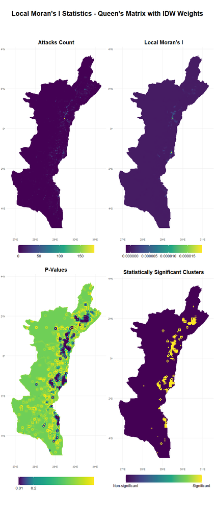

```r
# Create a neighbors list and spatial weights using IDW (only once, as spatial geometries are the same)

final_net.nb <- poly2nb(as_Spatial(final_net.sf.attacks_train), queen=TRUE)
final_net.weights <- nb2listwdist(final_net.nb, as_Spatial(final_net.sf.attacks_train), type = "idw", alpha = 2)

# Use the same spatial weights for all datasets, since spatial observations are identical
final_net.attacks_train.weights <- final_net.weights
final_net.attacks_test.weights <- final_net.weights

final_net.attacks_train.nb <- final_net.nb
final_net.attacks_test.nb <- final_net.nb

# Save objects
# saveRDS(final_net.attacks_train.nb, file = "final_net.attacks_train.nb.rds", compress = TRUE)
# saveRDS(final_net.attacks_train.weights, file = "final_net.attacks_train.weights.rds", compress = TRUE)

# saveRDS(final_net.attacks_test.nb, file = "final_net.attacks_test.nb.rds", compress = TRUE)
# saveRDS(final_net.attacks_test.weights, file = "final_net.attacks_test.weights.rds", compress = TRUE)


# final_net.attacks_train.nb <- readRDS(file = "final_net.attacks_train.nb.rds")
# final_net.attacks_train.weights <- readRDS(file = "final_net.attacks_train.weights.rds")
# final_net.attacks_test.nb <- readRDS(file = "final_net.attacks_test.nb.rds")
# final_net.attacks_test.weights <- readRDS(file = "final_net.attacks_test.weights.rds")


# Calculate Local Moran's I
local_morans.attacks_train <- as.data.frame(localmoran(final_net.sf.attacks_train$countAttacks, final_net.attacks_train.weights))


final_net.attacks_train.localMorans <-
  cbind(local_morans.attacks_train, as.data.frame(final_net.sf.attacks_train)) %>%
  st_sf() %>%
  dplyr::select(Attacks_Count = countAttacks,
                Local_Morans_I = Ii,
                P_Value = `Pr(z != E(Ii))`) %>%
  mutate(Significant_Clustering = ifelse(P_Value <= 0.05, 1, 0)) %>%
  tidyr::gather(Variable, Value, -geometry)


# Attacks Train
# Define custom titles for each map
custom_titles.attacks <- c("Attacks_Count" = "Attacks Count",
                   "Local_Morans_I" = "Local Moran's I",
                   "P_Value" = "P-Values",
                   "Significant_Clustering" = "Statistically Significant Clusters")

vars <- unique(final_net.attacks_train.localMorans$Variable)

# Create a list to store the ggplot objects
varList <- vector("list", length(vars))
names(varList) <- vars


for(var_name in vars){
  data_to_plot <- final_net.attacks_train.localMorans %>%
    filter(Variable == var_name)

  plot <- ggplot(data_to_plot, aes(fill = Value)) +
    geom_sf(color = NA) +
    labs(title = custom_titles.attacks[var_name]) +
    theme_minimal() +
    theme(plot.title = element_text(size = 20, face = "bold", hjust = 0.5),
          legend.position = "bottom",
          legend.title = element_blank(),
          legend.text = element_text(size = 14),
          legend.key.height = unit(2, 'lines'),
          legend.key.width = unit(2, 'cm'))

  if(var_name == "P_Value"){
    plot <- plot + scale_fill_gradientn(
      name = NULL, # Removes the legend title
      colours = viridis(256),
      values = scales::rescale(c(0, 0.2, 1)),
      breaks = c(0.01, 0.2),
      labels = c("0.01", "0.2"),
      guide = guide_colorbar(
        title = "",
        barwidth = 19.5,
        barheight = 2.1,
        label.theme = element_text(size = 14),
        title.position = "top",
        title.hjust = 0.5
      )
    )
  } else if(var_name == "Significant_Clustering") {
    plot <- plot +
      scale_fill_viridis_c(
        name = "Cluster Significance",
        begin = 0,
        end = 1,
        # direction = -1,
        labels = c("Non-significant", "Significant"),
        breaks = c(0, 1)
      )
  } else {
    plot <- plot + scale_fill_viridis_c(
      name = NULL, # Removes the legend title
      option = "viridis",
      begin = 0,
      end = 1
    )
  }

  varList[[var_name]] <- plot
}


# Convert each ggplot object in varList to a grob
varListGrob <- lapply(varList, ggplotGrob)

dev.size("in")

# For example, c(1, 0.1, 1) would mean both rows are the same height, with some space between
# Define widths for two columns only
row_heights <- unit(c(0.50, -0.06, 0.50), "npc")
column_widths <- unit(c(0.5, 0.5), "npc") # Equal column widths, adjust the numbers to change spacing

# Arrange the plots with specified space between rows
gtable_output <- gridExtra::grid.arrange(
  grobs = varListGrob,
  ncol = 2,
  layout_matrix = rbind(c(1, 2), c(NA, NA), c(3, 4)),  # Add a row of NAs for spacing
  top = grid::textGrob("Local Moran's I Statistics - Queen's Matrix with IDW Weights", gp = grid::gpar(fontsize = 25, fontface = "bold"), vjust = 0),
  heights = row_heights,
  widths = column_widths
)

# Save the grid.arrange plot as a PNG file
png("local_morans_i_exploratory_analysis-idw_queens.png", width = 800, height = 800 / (8.4375/20.5))

grid::grid.draw(gtable_output)
```

#### **2nd Map (1st Row, 2nd Column) - Local Moran’s I Statistics:** This map displays the Local Moran’s I statistic for each location, which measures spatial autocorrelation. Hot spots are identified by positive and statistically significant Local Moran’s I values that indicate an area has a high number of attacks on civilians and is surrounded by areas with similarly high values. Cold spots are identified by negative and statistically significant Local Moran’s I values, where locations with low numbers of attacks are surrounded by areas with similarly low values. Local Moran’s I values nearest to 0, regardless of their statistical significance, typically indicate no strong spatial autocorrelation (no significant clustering of similar or dissimilar values).

#### As you can see, there appear to only be a few places on this map - including the north-eastern and central-eastern areas that have hot spots of a relatively high concentration of attacks on civilians. A Local Moran’s I value of 0.0000187829661 - which is the highest value detected in the map - would appear to suggest a very low degree of spatial autocorrelation, or spatial clustering of similar high values (hotspots). However, these very low Local Moran’s I values are misleading at face value. Allow me to explain:

#### While Global Moran’s I values are always between +1 and -1, this is not true of Local Moran’s I values. If I were to not use IDW weights for my Queen’s contiguity matrix, the Local Moran’s I values would be much higher. IDW is a commonly used method to reflect the idea that spatial influence decreases as distance increases. This is a reasonable assumption in this project, as attacks occurring in one region are more likely to affect nearby regions more than distant ones.

#### The alpha parameter controls the rate of decay. In my case, alpha = 2 means that spatial influence diminishes quadratically with distance. A higher alpha (e.g., alpha = 3) might overly penalize distant neighbors, potentially ignoring relevant distant spatial interactions. Conversely, a lower alpha (e.g., alpha = 1) might not sufficiently reduce the influence of local points, leading to an overestimation of spatial dependence. Alpha = 2 strikes a balance.

#### Local Moran’s I values are more likely to be higher when using the row-standardized contiguity-based weighting matrix (style = “W”) compared to IDW with alpha = 2. First, this is because non-IDW contiguity-based weights tend to capture broader local spatial patterns by giving each neighbor relatively equal importance. However, it may not be realistic for events transpiring hundreds of miles away to be as likely to have the same impact on the number of attacks occurring against civilians as events transpiring only a few miles away.

#### Second, this type of weights matrix ensures the sum of weights for each observation equals 1. The calculation of Local Moran’s I involves multiplying the deviation of each observation by the weighted sum of the deviations of its neighbors. If certain observations have values that are significantly higher than the mean and are surrounded by neighbors with similarly high values, the Local Moran’s I for that point can be quite large.

#### Third, IDW with alpha = 2 strongly diminishes the influence of distant neighbors, focusing mostly on close neighbors. This can result in very low Local Moran’s I values because distant points are assigned very little weight, and the number of influential neighbors is small.

#### **3rd Map (2nd Row, 1st Column) - P-Values:** This map shows the p-values associated with the Local Moran’s I statistic. Areas with low p-values (dark blue areas) suggest that the observed spatial pattern (whether a hot spot or cold spot) is statistically significant, whereas areas with high p-values (green and yellow areas) suggest the observed pattern could be due to random spatial processes. We can see most areas on the map are not statistically significant, with the exception of the blue and purple clusters mostly along the eastern parts of the map.

#### **4th Map (2nd Row, 2nd Column) - Statistically Significant Clustering:** This map combinbes the Moran’s I values and p-values when using IDW weights, indicating significant spatial hot spots and cold spots of attacks. Areas marked in bright colors (light yellow) represent hot spots and cold spots where the Local Moran’s I statistic is significantly positive (p-value <= 0.05). The very large proportion of dark areas indicate non-statistically significant clustering, meaning spatial autocorrelation was not found to be much more likely than pure chance. Once again, statistically significant clusters mostly exist along the eastern part of the map. The main difference between plots 3 and 4 is that plot 3 provides a continuous range of p-values while the 4th plot categorically indicates the presence or absence of significant clustering.

#### Now, having performed exploratory data analysis with Local Moran’s I values, I will add 2 more features:

#### Variable: **Grid cell locations with Moran’s I p-values that are extremely statistically significant at p ≤ 0.0000001**

#### Variable: **Distance from each grid cell location to the nearest extremely statistically significant grid cell location**

```r
# Extremely statistically significant clustering:

# The following function which calculates the average distance from each and every spatial point to its nearest neighbor can be found on https://raw.githubusercontent.com/urbanSpatial/Public-Policy-Analytics-Landing/master/functions.r as nn_function:

library(FNN)
library(tibble)
library(tidyr)

dist_2_nearest_neighbor <- function(measureFrom, measureTo, k) {
  measureFrom_Matrix <-
    as.matrix(measureFrom)
  measureTo_Matrix <-
    as.matrix(measureTo)
  nn <-
    get.knnx(measureTo, measureFrom, k)$nn.dist
  output <-
    as.data.frame(nn) %>%
    rownames_to_column(var = "thisPoint") %>%
    gather(points, point_distance, V1:ncol(.)) %>%
    arrange(as.numeric(thisPoint)) %>%
    group_by(thisPoint) %>%
    summarize(pointDistance = mean(point_distance)) %>%
    arrange(as.numeric(thisPoint)) %>%
    dplyr::select(-thisPoint) %>%
    pull()

  return(output)
}

# Calculate whether each observation is highly statistically significant (1) or not (0)
final_net.sf.attacks_train <- final_net.sf.attacks_train %>%
  mutate(attacks.HiSig = ifelse(localmoran(countAttacks, final_net.attacks_train.weights)[,5] <= 0.0000001, 1, 0))

# Calculate distances from each grid cell to the nearest highly statistically significant grid cell
final_net.sf.attacks_train <- final_net.sf.attacks_train %>%
  mutate(attacks.HiSig.dist = dist_2_nearest_neighbor(
    st_coordinates(st_centroid(final_net.sf.attacks_train)),
    st_coordinates(st_centroid(filter(final_net.sf.attacks_train, attacks.HiSig == 1))),
    1
  ))

# Calculate whether each observation is highly statistically significant (1) or not (0)
final_net.sf.attacks_test <- final_net.sf.attacks_test %>%
  mutate(attacks.HiSig = ifelse(localmoran(countAttacks, final_net.attacks_test.weights)[,5] <= 0.0000001, 1, 0))

# Calculate distances from each grid cell to the nearest highly statistically significant grid cell
final_net.sf.attacks_test <- final_net.sf.attacks_test %>%
  mutate(attacks.HiSig.dist = dist_2_nearest_neighbor(
    st_coordinates(st_centroid(final_net.sf.attacks_test)),
    st_coordinates(st_centroid(filter(final_net.sf.attacks_test, attacks.HiSig == 1))),
    1
  ))

# Calculate whether each observation is highly statistically significant (1) or not (0)
final_net.sf.fatalities_train <- final_net.sf.fatalities_train %>%
  mutate(fatalities.HiSig = ifelse(localmoran(fatalities, final_net.fatalities_train.weights)[,5] <= 0.0000001, 1, 0))

# Calculate distances from each grid cell to the nearest highly statistically significant grid cell
final_net.sf.fatalities_train <- final_net.sf.fatalities_train %>%
  mutate(fatalities.HiSig.dist = dist_2_nearest_neighbor(
    st_coordinates(st_centroid(final_net.sf.fatalities_train)),
    st_coordinates(st_centroid(filter(final_net.sf.fatalities_train, fatalities.HiSig == 1))),
    1
  ))

# Calculate whether each observation is highly statistically significant (1) or not (0)
final_net.sf.fatalities_test <- final_net.sf.fatalities_test %>%
  mutate(fatalities.HiSig = ifelse(localmoran(fatalities, final_net.fatalities_test.weights)[,5] <= 0.0000001, 1, 0))

# Calculate distances from each grid cell to the nearest highly statistically significant grid cell
final_net.sf.fatalities_test <- final_net.sf.fatalities_test %>%
  mutate(fatalities.HiSig.dist = dist_2_nearest_neighbor(
    st_coordinates(st_centroid(final_net.sf.fatalities_test)),
    st_coordinates(st_centroid(filter(final_net.sf.fatalities_test, fatalities.HiSig == 1))),
    1
  ))

# Save objects
# saveRDS(final_net.sf.attacks_train, file = "final_net.sf.attacks_train-after_adding_HiSig_and_HiSig.dist.rds", compress = TRUE)
# saveRDS(final_net.sf.attacks_test, file = "final_net.sf.attacks_test-after_adding_HiSig_and_HiSig.dist.rds", compress = TRUE)
```

#### The next map shows the distance from each grid cell to its nearest neighboring grid cell found to contain a extremely statistically significant spatial cluster of attacks against civilians. These extremely significant Local Moran’s I grid cells may be especially vulnerable to attacks.

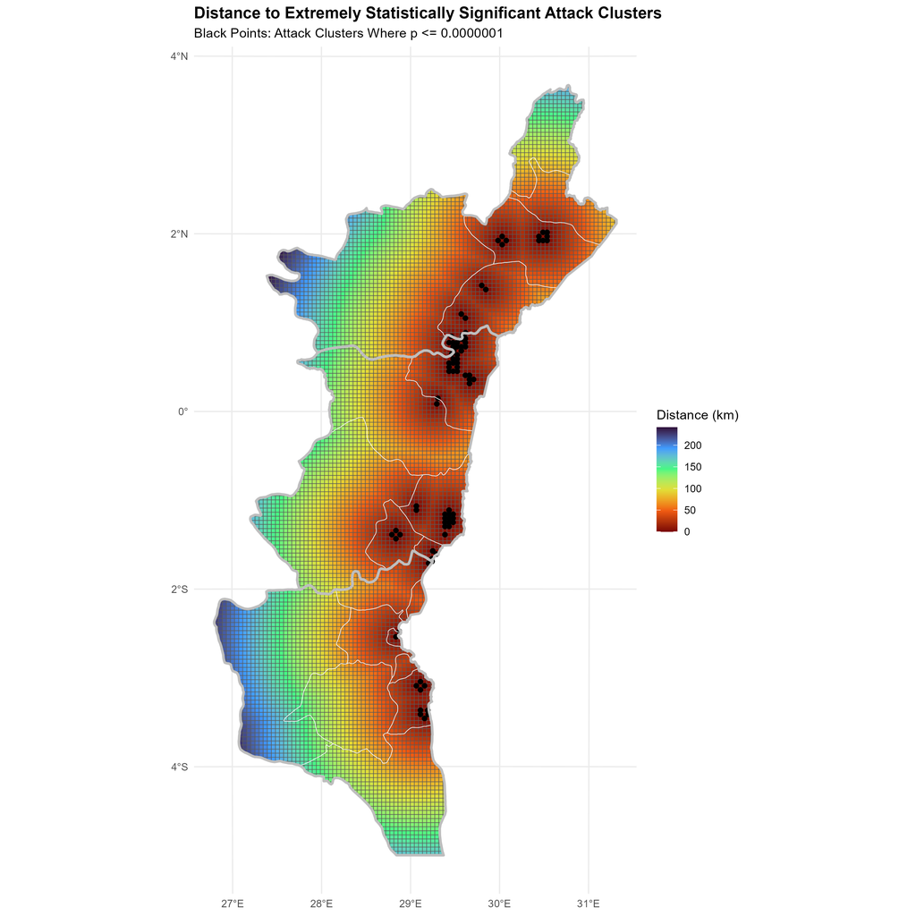

```r
ggplot() +
  geom_sf(data = final_net.sf.attacks_train, aes(fill = attacks.HiSig.dist / 1000), show.legend=TRUE) +
  # geom_sf(data=main_streets, colour="white", size=1) +
  geom_sf(data = filter(final_net.sf.attacks_train, attacks.HiSig == 1) %>% st_centroid(), colour = "black") +
  scale_fill_viridis_c(name = "Distance (km)", option = "H", direction = -1) +
  geom_sf(data = e_drc_adm2_map, fill = NA, color = "white", size = 0.1) +
  geom_sf(data = e_drc_adm1_map, fill = NA, color = "grey", linewidth = 1) +
  labs(title = "Distance to Extremely Statistically Significant Attack Clusters",
       subtitle = "Black Points: Attack Clusters Where p <= 0.0000001") +
  theme_minimal() +
  theme(
    plot.title = element_text(face = "bold")
  ) +
  coord_sf()
```